# Simulations of Special School Closures in Bavaria

Technical Report

Author

Nikola Ebenbeck

Published

February 25, 2026

# 1. Set up Environment

This analysis relies on several R packages that serve distinct methodological purposes. Data wrangling and transformation are conducted using the **tidyverse**, which provides a consistent grammar for filtering, reshaping, and aggregating data. Color scales that are accessible to readers with color-vision deficiencies are implemented using **khroma**. The packages **httr** and **jsonlite** enable communication with web services and the processing of JSON responses, which is required for retrieving geographic coordinates via the OpenStreetMap Nominatim API. Spatial data structures and georeferenced objects are handled using the **sf** package, while ggspatial provides cartographic elements such as scale annotations for map visualizations. Geographic distance calculations are performed using the **geosphere** package. Finally, **knitr** ensures consistent formatting of tables and outputs in the HTML report.

```r
library(tidyverse)        # Data Wrangling
library(khroma)           # Color-blind Color Scales
library(jsonlite)         # Koordinatenabruf
library(httr)             # Nominatim
library(sf)               # Spatial Data Frames
library(ggspatial)        # Annotation Scale for Maps
library(geosphere)        # Distance Matrix
library(knitr)            # Für HTML Output
```

# 2. Data Basis

The empirical foundation of this study consists of several administrative datasets, some of which are not publicly accessible. For this reason, only a structured overview of the data architecture is provided here, rather than the full datasets themselves.

## *2.1 Primary and Special School Studens in Bavaria*

The student-level datasets include 442,338 primary school students and 55,055 special school students enrolled in Bavaria in the 2020/21 school year. Each observation represents an individual student. The datasets contain information on the school identifier (Schulnummer), district (Kreis), municipality code (Gemeindekennzahl), gender (Geschlecht), and several variables related to migration background (Migrationshintergrund). Although migration-related variables are available, they are not used in the present analysis.

Crucially, the datasets also include information on students’ special educational needs (SEN; Förderschwerpunkt). This variable allows for the identification and aggregation of students with SEN across schools and districts, forming the basis for the simulation of redistribution scenarios.

The following code excerpts display the first rows of the primary and special school student datasets to illustrate their structure.

```r
head(PS) # Primary Schools
```

| ï..Jahr | Schulart | Schulnummer | Kreis | Gemeindekennzahl | Geschlecht | Kontinent | UNSD.Region | Migrationshintergrund | FÃ.rderschwerpunkt.des.SchÃ.lers | MSD.FÃ.rderschwerpunkt |
| --- | --- | --- | --- | --- | --- | --- | --- | --- | --- | --- |
| 2020 | Grundschule | 1203 | Altötting | 9171125 | männlich |  |  | Nein | Nein | Nein |
| 2020 | Grundschule | 1203 | Altötting | 9171125 | männlich |  |  | Nein | Nein | Nein |
| 2020 | Grundschule | 1203 | Altötting | 9171125 | männlich |  |  | Nein | Nein | Nein |
| 2020 | Grundschule | 1203 | Altötting | 9171125 | männlich |  |  | Nein | Nein | Nein |
| 2020 | Grundschule | 1203 | Altötting | 9171125 | männlich |  |  | Nein | Nein | Nein |
| 2020 | Grundschule | 1203 | Altötting | 9171125 | männlich |  |  | Nein | Nein | Nein |

```r
head(SS) # Special Schools
```

| ï..Berichtsjahr | Schulart | Schulnummer | Kreis | Gemeindekennzahl | Geschlecht | Kontinent | UNSD.Region | Migrationshintergrund | FÃ.rderschwerpunkt.des.SchÃ.lers | MSD.FÃ.rderschwerpunkt |
| --- | --- | --- | --- | --- | --- | --- | --- | --- | --- | --- |
| 2020 | Förderzentren | 753 | Krfr. St. München | 162000 | männlich |  |  | Nein | Ja | Nein |
| 2020 | Förderzentren | 753 | Krfr. St. München | 162000 | männlich |  |  | Nein | Ja | Nein |
| 2020 | Förderzentren | 753 | Krfr. St. München | 162000 | männlich |  |  | Nein | Ja | Nein |
| 2020 | Förderzentren | 753 | Krfr. St. München | 162000 | männlich |  |  | Nein | Ja | Nein |
| 2020 | Förderzentren | 753 | Krfr. St. München | 162000 | weiblich |  |  | Nein | Ja | Nein |
| 2020 | Förderzentren | 753 | Krfr. St. München | 162000 | männlich |  |  | Nein | Ja | Nein |

## *2.2 Locations of Primary and Special Schools in Bavaria*

A separate dataset provides structural information on all primary and special schools in Bavaria for the years 2010, 2015, and 2020. Each school is identified by its unique school number (Schulnummer). Additional variables include the district code (RS_Kreis), school type (Schulart), address information (street, postal code, city), municipality, and settlement structure type (KTYP4).

This dataset serves as the structural backbone for linking student-level data to institutional and spatial characteristics of schools.

```r
head(Geo)
```

| Schulnummer | RS_Kreis | Schulart | Schultyp | Strasse | PLZ | Ort | RS_Gemeinde | SN_KTYP4 | KTYP4 | Jahr | GEN |
| --- | --- | --- | --- | --- | --- | --- | --- | --- | --- | --- | --- |
| 1 | 9574 | Gymnasien | Gymnasien | Fischbacher Str. 23 | 90518 | Altdorf b.Nuernberg | 9574112 | 2 | Staedtische Kreise | 2015 | Nuernberger Land |
| 1 | 9574 | Gymnasien | Gymnasien | Fischbacher Str. 23 | 90518 | Altdorf b.Nuernberg | 9574112 | 2 | Staedtische Kreise | 2020 | Nuernberger Land |
| 1 | 9574 | Gymnasien | Gymnasien | Fischbacher Str. 23 | 90518 | Altdorf b.Nuernberg | 9574112 | 2 | Staedtische Kreise | 2010 | Nuernberger Land |
| 2 | 9171 | Gymnasien | Gymnasien | Neuoettinger Str. 8 | 84503 | Altoetting | 9171111 | 2 | Staedtische Kreise | 2010 | Altoetting |
| 2 | 9171 | Gymnasien | Gymnasien | Neuoettinger Str. 8 | 84503 | Altoetting | 9171111 | 2 | Staedtische Kreise | 2015 | Altoetting |
| 2 | 9171 | Gymnasien | Gymnasien | Neuoettinger Str. 8 | 84503 | Altoetting | 9171111 | 2 | Staedtische Kreise | 2020 | Altoetting |

## *2.3 Shape Files of Bavaria and Bavarian districts*

Spatial analyses and visualizations are based on official shapefiles containing georeferenced polygon data. One shapefile represents the federal state of Bavaria, while another provides district-level boundaries for all Bavarian districts. These spatial objects enable the cartographic representation of schools, districts, and aggregated indicators such as student numbers or teacher hours.

```r
head(bavaria) # Bavaria
```

| ADE | GF | BSG | ARS | AGS | SDV_ARS | GEN | BEZ | IBZ | BEM | NBD | SN_L | SN_R | SN_K | SN_V1 | SN_V2 | SN_G | FK_S3 | NUTS | ARS_0 | AGS_0 | WSK | DEBKG_ID | RS | SDV_RS | RS_0 | geometry |
| --- | --- | --- | --- | --- | --- | --- | --- | --- | --- | --- | --- | --- | --- | --- | --- | --- | --- | --- | --- | --- | --- | --- | --- | --- | --- | --- |
| 2 | 4 | 1 | 01 | 01 | 010020000000 | Schleswig-Holstein | Land | 20 | – | ja | 01 | 0 | 00 | 00 | 00 | 000 | 0 | DEF | 010000000000 | 01000000 | 2012-02-01 | DEBKGDL200000029 | 01 | 010020000000 | 010000000000 | MULTIPOLYGON (((464810.7 61… |
| 2 | 4 | 1 | 02 | 02 | 020000000000 | Hamburg | Freie und Hansestadt | 22 | – | ja | 02 | 0 | 00 | 00 | 00 | 000 | 0 | DE6 | 020000000000 | 02000000 | 1974-01-01 | DEBKGDL20000E6GD | 02 | 020000000000 | 020000000000 | MULTIPOLYGON (((578219 5954… |
| 2 | 4 | 1 | 03 | 03 | 032410001001 | Niedersachsen | Land | 20 | – | ja | 03 | 0 | 00 | 00 | 00 | 000 | 0 | DE9 | 030000000000 | 03000000 | 2015-01-01 | DEBKGDL20000E6EW | 03 | 032410001001 | 030000000000 | MULTIPOLYGON (((479451.1 59… |
| 2 | 4 | 1 | 04 | 04 | 040110000000 | Bremen | Freie Hansestadt | 23 | – | ja | 04 | 0 | 00 | 00 | 00 | 000 | 0 | DE5 | 040000000000 | 04000000 | 2010-01-01 | DEBKGDL20000E0SF | 04 | 040110000000 | 040000000000 | MULTIPOLYGON (((466930.3 58… |
| 2 | 4 | 1 | 05 | 05 | 051110000000 | Nordrhein-Westfalen | Land | 20 | – | ja | 05 | 0 | 00 | 00 | 00 | 000 | 0 | DEA | 050000000000 | 05000000 | 2009-11-01 | DEBKGDL20000E6GR | 05 | 051110000000 | 050000000000 | MULTIPOLYGON (((477607.3 58… |
| 2 | 4 | 1 | 06 | 06 | 064140000000 | Hessen | Land | 20 | – | ja | 06 | 0 | 00 | 00 | 00 | 000 | 0 | DE7 | 060000000000 | 06000000 | 2015-01-01 | DEBKGDL20000E3LK | 06 | 064140000000 | 060000000000 | MULTIPOLYGON (((534242 5721… |

```r
head(district) # Districts of Bavaria
```

| ADE | GF | BSG | ARS | AGS | SDV_ARS | GEN | BEZ | IBZ | BEM | NBD | SN_L | SN_R | SN_K | SN_V1 | SN_V2 | SN_G | FK_S3 | NUTS | ARS_0 | AGS_0 | WSK | DEBKG_ID | RS | SDV_RS | RS_0 | geometry |
| --- | --- | --- | --- | --- | --- | --- | --- | --- | --- | --- | --- | --- | --- | --- | --- | --- | --- | --- | --- | --- | --- | --- | --- | --- | --- | --- |
| 4 | 4 | 1 | 01001 | 01001 | 010010000000 | Flensburg | Kreisfreie Stadt | 40 | – | ja | 01 | 0 | 01 | 00 | 00 | 000 | R | DEF01 | 010010000000 | 01001000 | 2008-01-01 | DEBKGDL20000002R | 01001 | 010010000000 | 010010000000 | MULTIPOLYGON (((526513.8 60… |
| 4 | 4 | 1 | 01002 | 01002 | 010020000000 | Kiel | Kreisfreie Stadt | 40 | – | ja | 01 | 0 | 02 | 00 | 00 | 000 | R | DEF02 | 010020000000 | 01002000 | 2006-01-01 | DEBKGDL20000E43X | 01002 | 010020000000 | 010020000000 | MULTIPOLYGON (((575841.6 60… |
| 4 | 4 | 1 | 01003 | 01003 | 010030000000 | Lübeck | Kreisfreie Stadt | 40 | – | ja | 01 | 0 | 03 | 00 | 00 | 000 | R | DEF03 | 010030000000 | 01003000 | 2006-02-01 | DEBKGDL20000DYM9 | 01003 | 010030000000 | 010030000000 | MULTIPOLYGON (((623056.2 59… |
| 4 | 4 | 1 | 01004 | 01004 | 010040000000 | Neumünster | Kreisfreie Stadt | 40 | – | ja | 01 | 0 | 04 | 00 | 00 | 000 | R | DEF04 | 010040000000 | 01004000 | 1970-04-26 | DEBKGDL20000E4KX | 01004 | 010040000000 | 010040000000 | MULTIPOLYGON (((565015.7 60… |
| 4 | 4 | 1 | 01051 | 01051 | 010510044044 | Dithmarschen | Kreis | 42 | – | ja | 01 | 0 | 51 | 00 | 00 | 000 | R | DEF05 | 010510000000 | 01051000 | 2011-08-01 | DEBKGDL20000E14G | 01051 | 010510044044 | 010510000000 | MULTIPOLYGON (((505053.4 60… |
| 4 | 4 | 1 | 01053 | 01053 | 010530100100 | Herzogtum Lauenburg | Kreis | 42 | – | ja | 01 | 0 | 53 | 00 | 00 | 000 | R | DEF06 | 010530000000 | 01053000 | 2009-01-01 | DEBKGDL20000DYKR | 01053 | 010530100100 | 010530000000 | MULTIPOLYGON (((614093.1 59… |

## *2.4 Information on Funding Types of Schools*

An additional dataset contains information on the funding structure of schools, distinguishing between publicly funded and privately funded institutions. Schools are identified via their school number (Schulnummer). This information is used to exclude privately funded primary schools from certain simulation scenarios in order to maintain comparability within the public education system.

```r
head(funding)
```

| Schulnummer | RS_Kreis | Schulart | Schultyp | Funding |
| --- | --- | --- | --- | --- |
| 753 | 9162 | Foerderzentren | KME | regulär |
| 1203 | 9171 | Grundschulen | Grund- u. Mittelschule | regulär |
| 1204 | 9171 | Grundschulen | Grund- u. Mittelschule | regulär |
| 1205 | 9173 | Grundschulen | Grund- u. Mittelschule | regulär |
| 1206 | 9173 | Grundschulen | Grund- u. Mittelschule | regulär |
| 1207 | 9173 | Grundschulen | Grund- u. Mittelschule | regulär |

Together, these datasets allow for the integration of student-level information, school-level structural characteristics, and spatial data into a unified analytical framework for simulating structural transformations in the Bavarian school system.

# 3. Data Preperation

To construct the analytical baseline for the simulations, student-level data and structural school data are consolidated into a unified school-level dataset. The objective is to represent the current configuration of primary and special schools in Bavaria in the school year 2020/21. This baseline serves as the reference scenario against which all subsequent simulation models are compared.

## 3.1 Coordinates of Schools

Geographic coordinates for schools are retrieved using the OpenStreetMap Nominatim API. The geocoding procedure is based on the official address information of each school (street, postal code, city, country). To ensure compatibility with the API, addresses must be formatted in standard Latin characters (e.g., without German umlauts such as ä, ö, ü).

A custom function (`myOSMGeoCode`) is defined to query the API and extract longitude and latitude values from the JSON response. If a full address query does not return a result, the function performs a fallback query using only postal code and city. If both attempts fail, missing values are returned. This two-step procedure increases the robustness of the geocoding process.

The function is applied iteratively to all schools in the structural dataset. The resulting list of coordinates is then transformed into a data frame and merged with the original school-level information. Only schools from the year 2020 are retained, ensuring temporal consistency with the student-level data. The result is a dataset containing structural information and geographic coordinates for all relevant schools in Bavaria in 2020.

```r
myOSMGeoCode <- function(street, zip, city, country){

  url <-paste0(
    "http://nominatim.openstreetmap.org/search.php?q=",
    street, ",+",
    zip, "+",
    city, ",+",
    country,
    "&limit=1&format=json")

  osm.json <- fromJSON(url,simplify=FALSE)
  if(length(osm.json) > 0){
    r1 <- osm.json[[1]]$lon
    r2 <- osm.json[[1]]$lat
    r3 <- osm.json[[1]]$display_name
    r4 <- "OK"
    geocode <- c(r1,r2,r3,r4)
  } else{
    url <-paste0("http://nominatim.openstreetmap.org/search.php?q=", zip, "+", city, ",+", country, "&limit=1&format=json")
    osm.json <- fromJSON(url,simplify=FALSE)
    if(length(osm.json) > 0){
      r1 <- osm.json[[1]]$lon
      r2 <- osm.json[[1]]$lat
      r3 <- osm.json[[1]]$display_name
      r4 <- "ZIP"
      geocode <- c(r1,r2,r3,r4)
    } else{
      geocode <- c(NA,NA,NA,"NOK")
    }
  }
  return(geocode)
}

Koordinaten <- list()
for(i in 1:nrow(Geo)){
  z <- myOSMGeoCode(Geo$Strasse[i], Geo$PLZ[i], Geo$Ort[i], "Germany")
  Grundschulen_Koordinaten[[i]] <- z
}

Daten_Schulen_mit_Koordinaten <- Koordinaten %>%
  as.data.frame() %>% t() %>% as.data.frame() %>% # Data Transformation
  setNames(c("lon", "lat")) %>%
  mutate(lat = as.character(lat), lon = as.character(lon)) %>%
  bind_cols(Geo, .) %>%
  filter(Jahr=="2020") %>%
  select(-Schuljahr)
```

```r
head(Daten_Schulen_mit_Koordinaten)
```

| X | Schulnummer | Schulart | Kreis | Gemeindekennzahl | Schultyp | Strasse | PLZ | Ort | lat | lon |
| --- | --- | --- | --- | --- | --- | --- | --- | --- | --- | --- |
| 1 | 1 | Gymnasium | Nürnberger Land | 9574112 | Gymnasium | Fischbacher Str. 23 | 90518 | Altdorf b.Nürnberg | 49.38896 | 11.342510 |
| 2 | 2 | Gymnasium | Altötting | 9171111 | Gymnasium | Neuöttinger Str. 8 | 84503 | Altötting | 48.22988 | 12.679706 |
| 3 | 3 | Gymnasien | Lkr. Aschaffenburg | 671111 | Gymnasium | Brentanostr. 55 | 63755 | Alzenau | 50.09212 | 9.071371 |
| 4 | 4 | Gymnasium | Amberg, Kfr. St. | 9361000 | Gymnasium | Gymnasiumstr. 7 | 92224 | Amberg | 49.44091 | 11.849206 |
| 5 | 5 | Gymnasien | Krfr. St. Amberg | 361000 | Gymnasium | Moritzstr. 1 | 92224 | Amberg | 49.44409 | 11.876667 |
| 6 | 6 | Gymnasien | Krfr. St. Amberg | 361000 | Gymnasium | Kaiser-Wilhelm-Ring 7 | 92224 | Amberg | 49.44250 | 11.851924 |

## 3.2 Number of Students

The original student datasets are structured at the individual level, meaning that each row represents a single student. For the simulation analysis, however, the unit of analysis must be the school. Therefore, student counts are aggregated to the school level.

The total number of students enrolled at each school is calculated separately for special schools and primary schools. For special schools, it is assumed that approximately 50% of students are of primary school age. Since the present study focuses on primary education, only half of the special school student population is considered in the simulations. This assumption ensures that comparisons are restricted to the primary school sector.

The aggregated student counts are stored in a unified dataset containing school identifiers, school type (primary or special school), and the corresponding number of students.

```r
n_students <- bind_rows(
  SS %>% count(Schulnummer) %>% mutate(Type = "SS", n = n / 2),
  PS %>% count(Schulnummer) %>% mutate(Type = "PS"))

head(n_students)
```

| Schulnummer | n | Type |
| --- | --- | --- |
| 753 | 112.5 | SS |
| 1302 | 69.5 | SS |
| 1310 | 54.5 | SS |
| 1345 | 21.0 | SS |
| 1361 | 24.0 | SS |
| 1371 | 41.5 | SS |

## 3.2 Students with SEN in Primary Schools

In addition to total enrollment, the number of students with special educational needs (SEN) per primary school is calculated. This is done by filtering the primary school dataset for students identified as having an officially recognized SEN status and subsequently aggregating these cases at the school level.

The resulting dataset provides, for each primary school, the number of students with SEN. This variable is central for all redistribution simulations, as it determines both current support rates and the projected changes in inclusive scenarios.

```r
SPF <- data.frame(count(filter(PS, MSD.FÃ.rderschwerpunkt=="Ja"), Schulnummer))
head(SPF)
```

| Schulnummer | n |
| --- | --- |
| 1203 | 14 |
| 1204 | 5 |
| 1205 | 11 |
| 1206 | 7 |
| 1207 | 7 |
| 1208 | 1 |

## 4. Baseline Data

All previously prepared datasets are consolidated into a single analytical data frame representing the current structure of the Bavarian school system in the school year 2020/21. This integrated dataset forms the baseline scenario (Model 0), which serves as the reference point for all subsequent simulation models.

The merging process combines structural school data, geographic coordinates, student counts, SEN counts, and funding information. Schools are matched via their unique school identifier (Schulnummer). Privately funded primary schools are excluded from the analysis to ensure comparability within the public education sector. Special and primary schools remain in the dataset, while other school types are removed.

Student counts aggregated at the school level are joined to the structural data. The total number of enrolled students per school is stored in the variable `n_students_school`. Additionally, the number of students with special educational needs in primary schools is incorporated (`n_students_SEN_primary`). Since schools without SEN students would otherwise produce missing values after aggregation, missing values in this variable are recoded to zero for primary schools. This ensures that support rates can be calculated consistently across all institutions.

A binary indicator (`SFZ`) is created to distinguish special schools with a focus on learning, emotional-social development, or speech (coded as 1) from other types of special schools (coded as 0). This distinction is relevant for later simulation scenarios in which only specific types of special schools are closed.

At this stage, the dataset contains the following information for each school:

- Unique school identifier (Schulnummer)
- School type (Type: PS = primary school, SS = special school)
- Special school focus (Schultyp)
- Indicator for learning/behavior/speech special schools (SFZ)
- District identifier (RS_Kreis and Kreis)
- Municipality code (Gemeindekennzahl)
- Settlement structure type (SN_KTYP4)
- Address information (street, postal code, city)
- Geographic coordinates (latitude and longitude)
- Total number of students per school (`n_students_school`)
- Number of students with SEN at every primary school (`n_students_SEN_primary`)

The resulting dataset provides a harmonized, school-level representation of Bavaria’s primary and special education landscape in 2020/21. It integrates demographic, institutional, and spatial dimensions and establishes the empirical foundation for the simulation of alternative structural scenarios.

```r
data <-
  Daten_Schulen_mit_Koordinaten %>%
  left_join(select(funding, c(Schulnummer, Funding)), by="Schulnummer") %>%
  filter(!(Funding == "privat" & Schulart=="Grundschulen")) %>%
  left_join(n_students, by="Schulnummer") %>%
  rename(n_students_school=n) %>%
  left_join(SPF, by="Schulnummer") %>%
  rename(n_students_SEN_primary=n) %>%
  left_join(select(Geo, c(Schulnummer, RS_Kreis, SN_KTYP4)), by="Schulnummer") %>%
  filter(!is.na(Type))  %>% # Only special and primary schools
  mutate(n_students_SEN_primary = ifelse(Type == "PS",
    replace(n_students_SEN_primary, is.na(n_students_SEN_primary), 0),
    n_students_SEN_primary)) %>%
  mutate(SFZ = ifelse(Schultyp %in% c("ESE", "L", "Sprache", "SFZ"),1, 0)) %>%
  unique() %>%
  select(Schulnummer, Type, Schultyp, SFZ, SN_KTYP4, RS_Kreis, Kreis, Gemeindekennzahl, Strasse, PLZ, Ort, lat, lon, n_students_school, n_students_SEN_primary)

head(data)
```

|  | Schulnummer | Type | Schultyp | SFZ | SN_KTYP4 | RS_Kreis | Kreis | Gemeindekennzahl | Strasse | PLZ | Ort | lat | lon | n_students_school | n_students_SEN_primary |
| --- | --- | --- | --- | --- | --- | --- | --- | --- | --- | --- | --- | --- | --- | --- | --- |
| 1 | 753 | SS | KME | 0 | 1 | 9162 | Krfr. St. München | 162000 | Kurzstr. 2 | 81547 | München | 48.10467 | 11.56889 | 112.5 | NA |
| 4 | 1203 | PS | Grund- u. Mittelschule | 0 | 2 | 9171 | Altötting | 9171125 | Simbacher Str. 10/12 | 84524 | Neuötting | 48.24050 | 12.69665 | 299.0 | 14 |
| 6 | 1204 | PS | Grund- u. Mittelschule | 0 | 2 | 9171 | Altötting | 9171133 | Burgkirchener Str. 5 | 84577 | Tüßling | 48.21160 | 12.60343 | 104.0 | 5 |
| 8 | 1205 | PS | Grund- u. Mittelschule | 0 | 4 | 9173 | Bad Tölz-Wolfratshausen | 9173112 | Krankenhausstr. 45 | 83646 | Bad Tölz | 47.75604 | 11.56523 | 181.0 | 11 |
| 10 | 1206 | PS | Grund- u. Mittelschule | 0 | 4 | 9173 | Lkr. Bad Tölz-Wolfratshausen | 173112 | Jahnstr. 9 | 83646 | Bad Tölz | 47.76591 | 11.56249 | 201.0 | 7 |
| 12 | 1207 | PS | Grund- u. Mittelschule | 0 | 4 | 9173 | Lkr. Bad Tölz-Wolfratshausen | 173113 | Ludlmühlstr. 17 | 83671 | Benediktbeuern | 47.71205 | 11.42014 | 205.0 | 7 |

# 5. Modelling

To evaluate alternative structural configurations of the Bavarian primary and special education system, five simulation models are constructed and compared. These models differ in the extent to which special schools are closed and in the mechanism by which students with special educational needs (SEN) are redistributed.

The following scenarios are analyzed:

- **Model 0**: Current school system (baseline scenario)
- **Model 1**: Closure of all special schools
  - **Model 1A**: Redistribution to all primary schools within each district
  - **Model 1B**: Redistribution to selected inclusive primary schools targeting a 20% SEN rate
- **Model 2**: Closure of special schools for learning, behavior, and speech (SFZ only)
  - **Model 2A**: Redistribution to all primary schools within each district
  - **Model 2B**: Redistribution to selected inclusive primary schools targeting a 20% SEN rate

Each model is constructed at the school level and operates within district boundaries.

## 5.1 Model 0: Current situation in 2020/21

Model 0 represents the observed school structure in Bavaria in the 2020/21 school year. It serves as the empirical baseline against which all simulated scenarios are compared.

For each district (RS_Kreis), several aggregate indicators are calculated. These include the total number of students enrolled in primary and special schools combined (`n_students_district`), as well as separate totals for special schools (`n_students_SS_district`), primary schools (`n_students_PS_district`), and special schools for learning, behavior, and speech (`n_students_SFZ_district`). In addition, the total number of students without SEN is computed at the district level.

At the school level, the proportional size of each primary school within its district is calculated (`prop_PS_size_district`). This value represents the share of a given primary school in relation to the total primary school population of the district and later serves as a distribution weight in the redistribution models.

Furthermore, the support rate (`prop_support_rate`) is calculated for each primary school as the percentage of students with SEN relative to total enrollment. Finally, a variable (`n_students_PS_new`) is initialized with the current number of students per school; this variable will later be updated in the simulation scenarios.

Model 0 therefore provides a comprehensive description of student distribution across districts and schools under the current system.

```r
model_0 <- data %>%
  group_by(RS_Kreis) %>%
  mutate(n_students_district = sum(n_students_school)) %>%
  mutate(n_students_SS_district = sum(n_students_school[Type == "SS"])) %>%
  mutate(n_students_PS_district = sum(n_students_school[Type == "PS"])) %>%
  mutate(n_students_SFZ_district = sum(n_students_school[SFZ == 1])) %>%
  mutate(n_students_noSEN_district = sum(n_students_school - n_students_SEN_primary, na.rm=T)) %>%
  mutate(prop_PS_size_district = n_students_school/n_students_PS_district) %>%
  ungroup() %>%
  mutate(prop_support_rate = (n_students_SEN_primary/n_students_school)*100) %>%
  mutate(n_students_PS_new = n_students_school)

head(model_0)
```

| Schulnummer | Type | Schultyp | SFZ | SN_KTYP4 | RS_Kreis | Kreis | Gemeindekennzahl | Strasse | PLZ | Ort | lat | lon | n_students_school | n_students_SEN_primary | n_students_district | n_students_SS_district | n_students_PS_district | n_students_SFZ_district | n_students_noSEN_district | prop_PS_size_district | prop_support_rate | n_students_PS_new |
| --- | --- | --- | --- | --- | --- | --- | --- | --- | --- | --- | --- | --- | --- | --- | --- | --- | --- | --- | --- | --- | --- | --- |
| 753 | SS | KME | 0 | 1 | 9162 | Krfr. St. München | 162000 | Kurzstr. 2 | 81547 | München | 48.10467 | 11.56889 | 112.5 | NA | 48699.5 | 3008.5 | 45691 | 1800.0 | 44533 | 0.0024622 | NA | 112.5 |
| 1203 | PS | Grund- u. Mittelschule | 0 | 2 | 9171 | Altötting | 9171125 | Simbacher Str. 10/12 | 84524 | Neuötting | 48.24050 | 12.69665 | 299.0 | 14 | 4199.0 | 237.0 | 3962 | 186.5 | 3847 | 0.0754669 | 4.682274 | 299.0 |
| 1204 | PS | Grund- u. Mittelschule | 0 | 2 | 9171 | Altötting | 9171133 | Burgkirchener Str. 5 | 84577 | Tüßling | 48.21160 | 12.60343 | 104.0 | 5 | 4199.0 | 237.0 | 3962 | 186.5 | 3847 | 0.0262494 | 4.807692 | 104.0 |
| 1205 | PS | Grund- u. Mittelschule | 0 | 4 | 9173 | Bad Tölz-Wolfratshausen | 9173112 | Krankenhausstr. 45 | 83646 | Bad Tölz | 47.75604 | 11.56523 | 181.0 | 11 | 4717.0 | 252.0 | 4465 | 199.0 | 4305 | 0.0405375 | 6.077348 | 181.0 |
| 1206 | PS | Grund- u. Mittelschule | 0 | 4 | 9173 | Lkr. Bad Tölz-Wolfratshausen | 173112 | Jahnstr. 9 | 83646 | Bad Tölz | 47.76591 | 11.56249 | 201.0 | 7 | 4717.0 | 252.0 | 4465 | 199.0 | 4305 | 0.0450168 | 3.482587 | 201.0 |
| 1207 | PS | Grund- u. Mittelschule | 0 | 4 | 9173 | Lkr. Bad Tölz-Wolfratshausen | 173113 | Ludlmühlstr. 17 | 83671 | Benediktbeuern | 47.71205 | 11.42014 | 205.0 | 7 | 4717.0 | 252.0 | 4465 | 199.0 | 4305 | 0.0459127 | 3.414634 | 205.0 |

## 5.2 Model 1

Model 1 simulates a structural reform in which all special schools are closed. Students with SEN previously enrolled in special schools are redistributed within their respective districts. Two redistribution strategies are compared.

### 5.2.1 Model 1A

In Model 1A, all students from special schools are proportionally distributed across all primary schools within the same district. The redistribution is weighted according to the relative size of each primary school. Larger schools therefore receive a proportionally larger share of students with SEN.

For each primary school, the number of additional students (`n_students_PS_add`) is calculated as the district-level number of special school students multiplied by the school’s proportional size within the district. This results in a percentage growth indicator (`prop_students_PS_add`) reflecting how much each school would increase in size due to redistribution.

The new total enrollment per school (`n_students_PS_new`) is computed by adding the redistributed students to the original enrollment. A new support rate (`prop_support_rate_new`) is then calculated based on the updated enrollment figures. Hospital schools are excluded from closure and remain in the dataset. Finally, the updated number of students with SEN per school (`n_students_SEN_new`) is derived.

This scenario represents a fully decentralized inclusion model in which all primary schools share responsibility for formerly segregated students.

```r
model_1a <- model_0 %>%
  group_by(RS_Kreis) %>%
  mutate(n_students_PS_add = n_students_SS_district*prop_PS_size_district) %>%
  mutate(prop_students_PS_add = (n_students_PS_add/n_students_school)*100) %>%
  mutate(n_students_PS_new = n_students_school + n_students_PS_add) %>%
  mutate(prop_support_rate_new =
           ((n_students_SEN_primary + n_students_PS_add) / n_students_PS_new) *100) %>%
  filter(!(Type == "SS" & Schultyp != "Kranke")) %>%
  mutate(n_students_SEN_new = n_students_SEN_primary + n_students_PS_add)

head(model_1a)
```

| Schulnummer | Type | Schultyp | SFZ | SN_KTYP4 | RS_Kreis | Kreis | Gemeindekennzahl | Strasse | PLZ | Ort | lat | lon | n_students_school | n_students_SEN_primary | n_students_district | n_students_SS_district | n_students_PS_district | n_students_SFZ_district | n_students_noSEN_district | prop_PS_size_district | prop_support_rate | n_students_PS_new | n_students_PS_add | prop_students_PS_add | prop_support_rate_new | n_students_SEN_new |
| --- | --- | --- | --- | --- | --- | --- | --- | --- | --- | --- | --- | --- | --- | --- | --- | --- | --- | --- | --- | --- | --- | --- | --- | --- | --- | --- |
| 1203 | PS | Grund- u. Mittelschule | 0 | 2 | 9171 | Altötting | 9171125 | Simbacher Str. 10/12 | 84524 | Neuötting | 48.24050 | 12.69665 | 299 | 14 | 4199 | 237 | 3962 | 186.5 | 3847 | 0.0754669 | 4.6822742 | 316.8857 | 17.885664 | 5.981827 | 10.062198 | 31.885664 |
| 1204 | PS | Grund- u. Mittelschule | 0 | 2 | 9171 | Altötting | 9171133 | Burgkirchener Str. 5 | 84577 | Tüßling | 48.21160 | 12.60343 | 104 | 5 | 4199 | 237 | 3962 | 186.5 | 3847 | 0.0262494 | 4.8076923 | 110.2211 | 6.221101 | 5.981827 | 10.180537 | 11.221101 |
| 1205 | PS | Grund- u. Mittelschule | 0 | 4 | 9173 | Bad Tölz-Wolfratshausen | 9173112 | Krankenhausstr. 45 | 83646 | Bad Tölz | 47.75604 | 11.56523 | 181 | 11 | 4717 | 252 | 4465 | 199.0 | 4305 | 0.0405375 | 6.0773481 | 191.2155 | 10.215454 | 5.643897 | 11.095052 | 21.215453 |
| 1206 | PS | Grund- u. Mittelschule | 0 | 4 | 9173 | Lkr. Bad Tölz-Wolfratshausen | 173112 | Jahnstr. 9 | 83646 | Bad Tölz | 47.76591 | 11.56249 | 201 | 7 | 4717 | 252 | 4465 | 199.0 | 4305 | 0.0450168 | 3.4825871 | 212.3442 | 11.344233 | 5.643897 | 8.638913 | 18.344233 |
| 1207 | PS | Grund- u. Mittelschule | 0 | 4 | 9173 | Lkr. Bad Tölz-Wolfratshausen | 173113 | Ludlmühlstr. 17 | 83671 | Benediktbeuern | 47.71205 | 11.42014 | 205 | 7 | 4717 | 252 | 4465 | 199.0 | 4305 | 0.0459127 | 3.4146341 | 216.5700 | 11.569989 | 5.643897 | 8.574590 | 18.569989 |
| 1208 | PS | Grund- u. Mittelschule | 0 | 4 | 9173 | Lkr. Bad Tölz-Wolfratshausen | 173118 | Am Richteranger 12 - 18 | 83623 | Dietramszell | 47.84911 | 11.59473 | 159 | 1 | 4717 | 252 | 4465 | 199.0 | 4305 | 0.0356103 | 0.6289308 | 167.9738 | 8.973796 | 5.643897 | 5.937710 | 9.973796 |

### 5.2.2 Model 1B

Model 1B follows a more selective redistribution strategy. Instead of distributing students with SEN across all primary schools, only selected primary schools become inclusive schools. These schools are chosen based on size, with larger schools prioritized.

For each primary school, the number of additional students required to reach a target support rate of 20% is calculated. The underlying formula derives from the equation:

(a+x)/(b+x)=0.20(a + x) / (b + x) = 0.20(a+x)/(b+x)=0.20

where *a* is the current number of students with SEN, *b* is the current total number of students, and *x* is the number of additional students with SEN to be allocated.

Solving for *x* yields:

x=(0.2b−a)/0.8x = (0.2b - a) / 0.8x=(0.2b−a)/0.8

Schools that already exceed a 20% support rate do not receive additional students. Students from closed special schools are then allocated sequentially, starting with the largest schools and proceeding in descending order of school size, until all students are redistributed.

Cumulative allocation is tracked to ensure that the total number of redistributed students does not exceed the available number in each district. In districts with very small special school populations, the general allocation procedure may fail; these cases are handled manually to ensure full redistribution.

After redistribution, new enrollment figures and updated support rates are calculated. Model 1B therefore represents a concentrated inclusion model in which inclusion is institutionalized in selected, larger primary schools.

```r
model_1b <- model_0 %>%
  filter(!(Type == "SS" & Schultyp != "Kranke")) %>%
  group_by(RS_Kreis) %>%
  arrange(desc(n_students_school)) %>%
  mutate(Rangordnung = row_number()) %>%
  mutate(n_students_PS_add =
    ((0.2*n_students_school)-n_students_SEN_primary) / 0.8) %>%
  mutate(n_students_PS_add = ifelse(
    n_students_PS_add < 0, 0, n_students_PS_add)) %>%
  mutate(z=cumsum(n_students_PS_add)) %>%
  mutate(z = ifelse(z>n_students_SS_district, NA, z)) %>%
  mutate(zmax = max(z, na.rm=T)) %>%
  mutate(n_students_PS_add = ifelse(is.na(z), n_students_PS_add==NA,
                                        n_students_PS_add)) %>%
  mutate(n_students_PS_add = ifelse(is.na(z) & !is.na(lag(z)),
                                        n_students_SS_district-zmax,
                                        n_students_PS_add)) %>%
  mutate(prop_students_PS_add = (n_students_PS_add/n_students_school)*100)
## Three districts have very few students at special schools. The pipe does
## not work for them, which is why those districts are calculated manually.
three_districts <- filter(model_1b, RS_Kreis %in% c(9472, 9475, 9778)) %>%
  mutate(n_students_PS_add = ifelse(
    row_number() == 1, n_students_SS_district, n_students_PS_add))
## The three districts now are again added to model_1b. This pipe further
## calculates how large the schools are after the special school closures and
## how many inclusive special schools there would be per district.
model_1b <- model_1b %>%
  filter(!(RS_Kreis %in% c(9472, 9475, 9778))) %>%
  rbind(three_districts) %>%
  select(-c(z, zmax)) %>%
  mutate(n_students_PS_new = n_students_school + n_students_PS_add) %>%
  mutate(prop_support_rate_new =
           ((n_students_SEN_primary+n_students_PS_add) / n_students_PS_new)*100) %>%
  mutate(prop_support_rate_new = ifelse(is.na(prop_support_rate_new),
                                        prop_support_rate,
                                        prop_support_rate_new)) %>%
  mutate(n_students_PS_new = case_when(is.na(n_students_PS_new) & Type == "PS" ~ n_students_school,
                                       TRUE ~ n_students_PS_new))

head(model_1b)
```

| Schulnummer | Type | Schultyp | SFZ | SN_KTYP4 | RS_Kreis | Kreis | Gemeindekennzahl | Strasse | PLZ | Ort | lat | lon | n_students_school | n_students_SEN_primary | n_students_district | n_students_SS_district | n_students_PS_district | n_students_SFZ_district | n_students_noSEN_district | prop_PS_size_district | prop_support_rate | n_students_PS_new | Rangordnung | n_students_PS_add | prop_students_PS_add | prop_support_rate_new |
| --- | --- | --- | --- | --- | --- | --- | --- | --- | --- | --- | --- | --- | --- | --- | --- | --- | --- | --- | --- | --- | --- | --- | --- | --- | --- | --- |
| 2240 | PS | Grund- u. Mittelschule | 0 | 1 | 9162 | München, Kfr. St. | 9162000 | Rotbuchenstr. 81 | 81547 | München | 48.09775 | 11.57429 | 699 | 3 | 48699.5 | 3008.5 | 45691 | 1800.0 | 44533 | 0.0152984 | 0.4291845 | 870.00 | 1 | 171.00 | 24.46352 | 20 |
| 8988 | PS | Grund- u. Mittelschule | 0 | 3 | 9773 | Lkr. Dillingen a.d.Donau | 773125 | Rosenstr. 3 | 89407 | Dillingen a.d.Donau | 48.57940 | 10.49430 | 670 | 31 | 3448.0 | 201.0 | 3247 | 140.5 | 3130 | 0.2063443 | 4.6268657 | 798.75 | 1 | 128.75 | 19.21642 | 20 |
| 6780 | PS | Grund- u. Mittelschule | 0 | 2 | 9572 | Erlangen-Höchstadt | 9572132 | Edergasse 17 | 91074 | Herzogenaurach | 49.57122 | 10.88681 | 603 | 12 | 5308.5 | 320.5 | 4988 | 285.5 | 4886 | 0.1208901 | 1.9900498 | 738.75 | 1 | 135.75 | 22.51244 | 20 |
| 2277 | PS | Grund- u. Mittelschule | 0 | 1 | 9162 | München, Kfr. St. | 9162000 | Turnerstr. 46 | 81827 | München | 48.11238 | 11.69503 | 582 | 5 | 48699.5 | 3008.5 | 45691 | 1800.0 | 44533 | 0.0127377 | 0.8591065 | 721.25 | 2 | 139.25 | 23.92612 | 20 |
| 2222 | PS | Grund- u. Mittelschule | 0 | 1 | 9162 | München, Kfr. St. | 9162000 | Manzostr. 79 | 80997 | München | 48.18389 | 11.48333 | 566 | 7 | 48699.5 | 3008.5 | 45691 | 1800.0 | 44533 | 0.0123876 | 1.2367491 | 698.75 | 3 | 132.75 | 23.45406 | 20 |
| 2131 | PS | Grund- u. Mittelschule | 0 | 1 | 9162 | Krfr. St. München | 162000 | Welzenbachstr. 12 | 80992 | München | 48.17524 | 11.51533 | 564 | 24 | 48699.5 | 3008.5 | 45691 | 1800.0 | 44533 | 0.0123438 | 4.2553191 | 675.00 | 4 | 111.00 | 19.68085 | 20 |

## 5.3 Model 2

Model 2 assumes a partial reform in which only special schools focusing on learning, behavior, and speech (SFZ) are closed. Other types of special schools remain operational. As in Model 1, two redistribution strategies are implemented.

### 5.3.1 Model 2A

Model 2A mirrors the logic of Model 1A but applies it only to students enrolled in SFZ schools. The number of students redistributed within each district corresponds to the total number of students in SFZ institutions. Redistribution across primary schools is again proportional to school size.

New enrollment figures and support rates are calculated accordingly. Special schools that are not classified as SFZ, as well as hospital schools, remain unaffected and are retained in the dataset.

```r
model_2a <- model_0 %>%
  group_by(RS_Kreis) %>%
  mutate(n_students_PS_add = n_students_SFZ_district*prop_PS_size_district) %>%
  mutate(prop_students_PS_add = (n_students_PS_add/n_students_school)*100) %>%
  mutate(n_students_PS_new = n_students_school + n_students_PS_add) %>%
  mutate(prop_support_rate_new =
           ((n_students_SEN_primary + n_students_PS_add) / n_students_PS_new)
         *100) %>%
  filter(!(Type == "SS" & SFZ == 1)) %>%
  mutate(n_students_SEN_new = n_students_SEN_primary + n_students_PS_add)

head(model_2a)
```

| Schulnummer | Type | Schultyp | SFZ | SN_KTYP4 | RS_Kreis | Kreis | Gemeindekennzahl | Strasse | PLZ | Ort | lat | lon | n_students_school | n_students_SEN_primary | n_students_district | n_students_SS_district | n_students_PS_district | n_students_SFZ_district | n_students_noSEN_district | prop_PS_size_district | prop_support_rate | n_students_PS_new | n_students_PS_add | prop_students_PS_add | prop_support_rate_new | n_students_SEN_new |
| --- | --- | --- | --- | --- | --- | --- | --- | --- | --- | --- | --- | --- | --- | --- | --- | --- | --- | --- | --- | --- | --- | --- | --- | --- | --- | --- |
| 753 | SS | KME | 0 | 1 | 9162 | Krfr. St. München | 162000 | Kurzstr. 2 | 81547 | München | 48.10467 | 11.56889 | 112.5 | NA | 48699.5 | 3008.5 | 45691 | 1800.0 | 44533 | 0.0024622 | NA | 116.9319 | 4.431945 | 3.939507 | NA | NA |
| 1203 | PS | Grund- u. Mittelschule | 0 | 2 | 9171 | Altötting | 9171125 | Simbacher Str. 10/12 | 84524 | Neuötting | 48.24050 | 12.69665 | 299.0 | 14 | 4199.0 | 237.0 | 3962 | 186.5 | 3847 | 0.0754669 | 4.682274 | 313.0746 | 14.074583 | 4.707219 | 8.967379 | 28.074583 |
| 1204 | PS | Grund- u. Mittelschule | 0 | 2 | 9171 | Altötting | 9171133 | Burgkirchener Str. 5 | 84577 | Tüßling | 48.21160 | 12.60343 | 104.0 | 5 | 4199.0 | 237.0 | 3962 | 186.5 | 3847 | 0.0262494 | 4.807692 | 108.8955 | 4.895507 | 4.707219 | 9.087158 | 9.895507 |
| 1205 | PS | Grund- u. Mittelschule | 0 | 4 | 9173 | Bad Tölz-Wolfratshausen | 9173112 | Krankenhausstr. 45 | 83646 | Bad Tölz | 47.75604 | 11.56523 | 181.0 | 11 | 4717.0 | 252.0 | 4465 | 199.0 | 4305 | 0.0405375 | 6.077348 | 189.0670 | 8.066965 | 4.456887 | 10.084768 | 19.066965 |
| 1206 | PS | Grund- u. Mittelschule | 0 | 4 | 9173 | Lkr. Bad Tölz-Wolfratshausen | 173112 | Jahnstr. 9 | 83646 | Bad Tölz | 47.76591 | 11.56249 | 201.0 | 7 | 4717.0 | 252.0 | 4465 | 199.0 | 4305 | 0.0450168 | 3.482587 | 209.9583 | 8.958343 | 4.456887 | 7.600719 | 15.958343 |
| 1207 | PS | Grund- u. Mittelschule | 0 | 4 | 9173 | Lkr. Bad Tölz-Wolfratshausen | 173113 | Ludlmühlstr. 17 | 83671 | Benediktbeuern | 47.71205 | 11.42014 | 205.0 | 7 | 4717.0 | 252.0 | 4465 | 199.0 | 4305 | 0.0459127 | 3.414634 | 214.1366 | 9.136618 | 4.456887 | 7.535665 | 16.136618 |

### 5.3.2 Model 2B

Model 2B combines the selective redistribution strategy of Model 1B with the partial closure logic of Model 2. Only students from SFZ schools are redistributed, and they are allocated to selected primary schools aiming for a 20% support rate.

As in Model 1B, schools are ranked by size, and the number of additional students required to reach the target support rate is calculated. Students are allocated sequentially until all eligible students are placed. Districts with very small SFZ populations are again treated manually to ensure proper redistribution.

After redistribution, updated enrollment numbers and support rates are calculated. Special schools that are not subject to closure are reintroduced into the dataset, ensuring that the final model accurately reflects the partial reform scenario.

```r
model_2b <- model_0 %>%
  filter(Type!="SS") %>%
  group_by(RS_Kreis) %>%
  arrange(desc(n_students_school)) %>%
  mutate(Rangordnung = row_number()) %>%
  mutate(n_students_PS_add =
           ((0.2*n_students_school)-n_students_SEN_primary) / 0.8) %>%
  mutate(n_students_PS_add = ifelse(
    n_students_PS_add < 0, 0, n_students_PS_add)) %>%
  mutate(z=cumsum(n_students_PS_add)) %>%
  mutate(z = ifelse(z>n_students_SFZ_district, NA, z)) %>%
  mutate(zmax = max(z, na.rm=T)) %>%
  mutate(n_students_PS_add = ifelse(is.na(z), n_students_PS_add==NA,
                                        n_students_PS_add)) %>%
  mutate(n_students_PS_add = ifelse(is.na(z) & !is.na(lag(z)),
                                        n_students_SFZ_district-zmax,
                                        n_students_PS_add)) %>%
  mutate(prop_students_PS_add = (n_students_PS_add/n_students_school)*100)
## Seven districts have very few students at SFZs. The pipe does not work for
## them, which is why those districts are calculated manually.
seven_districts <- filter(
  model_2b, RS_Kreis %in% c(9188, 9261, 9472, 9475, 9476, 9573, 9778)) %>%
  mutate(n_students_PS_add = ifelse(
    row_number() == 1, n_students_SFZ_district, n_students_PS_add))
## The three districts now are again added to model_2b. This pipe further
## calculates how large the schools are after the special school closures and
## how many inclusive special schools there would be per district.
model_2b <- model_2b %>%
  filter(!(RS_Kreis %in% c(9188, 9261, 9472, 9475, 9476, 9573, 9778))) %>%
  rbind(seven_districts) %>%
  select(-c(z, zmax)) %>%
  mutate(n_students_PS_new = n_students_school + n_students_PS_add)
## Support Rates are calculated
model_2b <- model_2b %>%
  mutate(prop_support_rate_new =
           ((n_students_SEN_primary+n_students_PS_add) / n_students_PS_new)*100) %>%
  mutate(prop_support_rate_new = case_when(
    is.na(prop_support_rate_new) ~ prop_support_rate,
    TRUE ~ prop_support_rate_new)) %>%
  mutate(n_students_PS_new = case_when(is.na(n_students_PS_new) & Type == "PS" ~ n_students_school,
                                       TRUE ~ n_students_PS_new))
## Other special schools were not closed and again added to the dataframe.
x <- model_0 %>% filter(Type == "SS" & SFZ == 0)
model_2b <- model_2b %>% rbind(x)
## Hospital schools are not closed and again added to the dataframe.
x <- model_0 %>% filter(Schultyp == "Kranke")
model_2b <- model_2b %>% rbind(x)

head(model_2b)
```

| Schulnummer | Type | Schultyp | SFZ | SN_KTYP4 | RS_Kreis | Kreis | Gemeindekennzahl | Strasse | PLZ | Ort | lat | lon | n_students_school | n_students_SEN_primary | n_students_district | n_students_SS_district | n_students_PS_district | n_students_SFZ_district | n_students_noSEN_district | prop_PS_size_district | prop_support_rate | n_students_PS_new | Rangordnung | n_students_PS_add | prop_students_PS_add | prop_support_rate_new |
| --- | --- | --- | --- | --- | --- | --- | --- | --- | --- | --- | --- | --- | --- | --- | --- | --- | --- | --- | --- | --- | --- | --- | --- | --- | --- | --- |
| 2240 | PS | Grund- u. Mittelschule | 0 | 1 | 9162 | München, Kfr. St. | 9162000 | Rotbuchenstr. 81 | 81547 | München | 48.09775 | 11.57429 | 699 | 3 | 48699.5 | 3008.5 | 45691 | 1800.0 | 44533 | 0.0152984 | 0.4291845 | 870.00 | 1 | 171.00 | 24.46352 | 20 |
| 8988 | PS | Grund- u. Mittelschule | 0 | 3 | 9773 | Lkr. Dillingen a.d.Donau | 773125 | Rosenstr. 3 | 89407 | Dillingen a.d.Donau | 48.57940 | 10.49430 | 670 | 31 | 3448.0 | 201.0 | 3247 | 140.5 | 3130 | 0.2063443 | 4.6268657 | 798.75 | 1 | 128.75 | 19.21642 | 20 |
| 6780 | PS | Grund- u. Mittelschule | 0 | 2 | 9572 | Erlangen-Höchstadt | 9572132 | Edergasse 17 | 91074 | Herzogenaurach | 49.57122 | 10.88681 | 603 | 12 | 5308.5 | 320.5 | 4988 | 285.5 | 4886 | 0.1208901 | 1.9900498 | 738.75 | 1 | 135.75 | 22.51244 | 20 |
| 2277 | PS | Grund- u. Mittelschule | 0 | 1 | 9162 | München, Kfr. St. | 9162000 | Turnerstr. 46 | 81827 | München | 48.11238 | 11.69503 | 582 | 5 | 48699.5 | 3008.5 | 45691 | 1800.0 | 44533 | 0.0127377 | 0.8591065 | 721.25 | 2 | 139.25 | 23.92612 | 20 |
| 2222 | PS | Grund- u. Mittelschule | 0 | 1 | 9162 | München, Kfr. St. | 9162000 | Manzostr. 79 | 80997 | München | 48.18389 | 11.48333 | 566 | 7 | 48699.5 | 3008.5 | 45691 | 1800.0 | 44533 | 0.0123876 | 1.2367491 | 698.75 | 3 | 132.75 | 23.45406 | 20 |
| 2131 | PS | Grund- u. Mittelschule | 0 | 1 | 9162 | Krfr. St. München | 162000 | Welzenbachstr. 12 | 80992 | München | 48.17524 | 11.51533 | 564 | 24 | 48699.5 | 3008.5 | 45691 | 1800.0 | 44533 | 0.0123438 | 4.2553191 | 675.00 | 4 | 111.00 | 19.68085 | 20 |

# 6. Cartographic Visualisation of Schools and Students

This section illustrates how geographic data can be visualised in R using the **sf** and **ggplot2** ecosystem. A key idea for readers without prior experience in geodata is that maps in R typically combine **two types of spatial objects**:

1. **Polygon layers** (e.g., administrative boundaries such as Bavaria or districts), usually stored as *sf* objects with a `geometry` column containing polygons.
2. **Point layers** (e.g., school locations), created from latitude/longitude coordinates and converted into *sf* point geometries.

The **sf** package is central because it stores spatial information in regular data frames while adding a special `geometry` column. Once a dataset is converted to an *sf* object, it can be plotted directly with **`geom_sf()`** in ggplot2. This provides a consistent workflow: map layers are simply added as successive ggplot layers, similar to other ggplot visualisations.

A second important concept is the **coordinate reference system (CRS)**. In this report, school coordinates are stored as latitude/longitude and therefore use **EPSG:4326** (WGS84), the standard geographic CRS used by GPS and OpenStreetMap. When converting tabular coordinates into an sf object, the CRS is explicitly declared to ensure that distances and spatial overlays are interpreted correctly.

Across all maps, the general strategy is:

- Use a polygon shapefile of Bavaria as a **background layer** (light fill, black border).
- Add school locations as **points** (sf points), coloured by a categorical variable. It is also possible to change the size of points by variable.
- Use accessible colour palettes from **khroma**, and keep the layout readable through a consistent theme and legend placement.

## 6.1 Map of Model 0 for all Bavaria

The first step is to prepare the point layer for schools. From the baseline model, only variables needed for mapping are selected (school type and coordinates). A new categorical variable (`Schule_Type`) is created to distinguish special school subtypes, including hospital schools. Records without coordinates are removed because they cannot be placed on a map.

The crucial transformation happens in `st_as_sf(coords = c("lon", "lat"), crs = 4326)`: this converts the ordinary data frame into an **sf point object**, where each row becomes a geographic point based on longitude and latitude.

The map itself is created by layering:

1. The polygon boundary of Bavaria (`bavaria`) as a background.
2. The special schools as points on top (`plot_0 %>% filter(Type == "SS")`), coloured by `Schule_Type`.

This produces a baseline visual overview of where special schools are located in Bavaria in 2020/21 and how they are distributed across space.

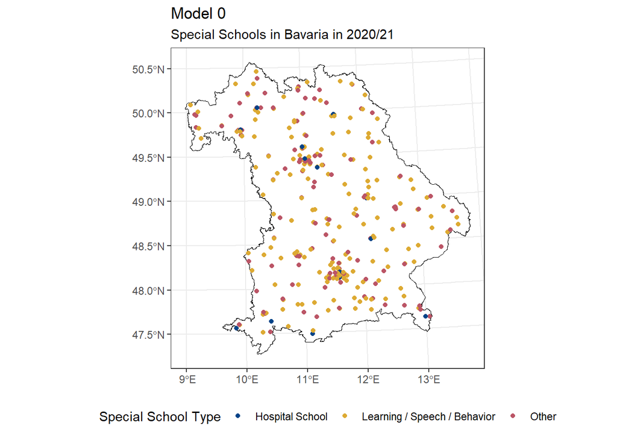

```r
plot_0 <- model_0 %>%
  select(Type, Schultyp, SFZ, RS_Kreis, lat, lon) %>%
  mutate(Schule_Type = case_when(Schultyp == "Kranke" ~ "Hospital School",
                             SFZ == "1" ~ "Learning / Speech / Behavior",
                             SFZ == "0" ~ "Other",
                             TRUE ~ "Primary School")) %>%
  filter(!is.na(lat)) %>% st_as_sf(coords = c("lon", "lat"), crs=4326)

ggplot() +
  geom_sf(data=bavaria %>% filter(GEN=="Bayern") %>% select(GEN),
          aes(), color="black", fill="white") +
  geom_sf(data=plot_0 %>% filter(Type == "SS"), aes(color=Schule_Type)) +
  scale_color_highcontrast() +
  theme_bw() +
  theme(legend.position = "bottom") +
  labs(color="Special School Type",
       title="Model 0",
       subtitle="Special Schools in Bavaria in 2020/21")
```

## 6.2 Maps of Model 1 A and B for all Bavaria

The mapping logic is the same as in Model 0: school-level information is reduced to relevant columns, a readable categorical label for school type is created, and the dataset is converted into an sf point object using longitude/latitude and CRS 4326.

In this figure, the plotted points represent the **special schools that remain** under the Model 1 scenario. Because Model 1 closes all special schools except hospital schools, the map provides a quick visual plausibility check: after applying the closure rule, the remaining special schools should mainly consist of hospital schools (depending on the underlying data).

Technically, this section demonstrates that once a mapping workflow is established (polygon background and point layer), it can be reused across scenarios by simply swapping the input model.

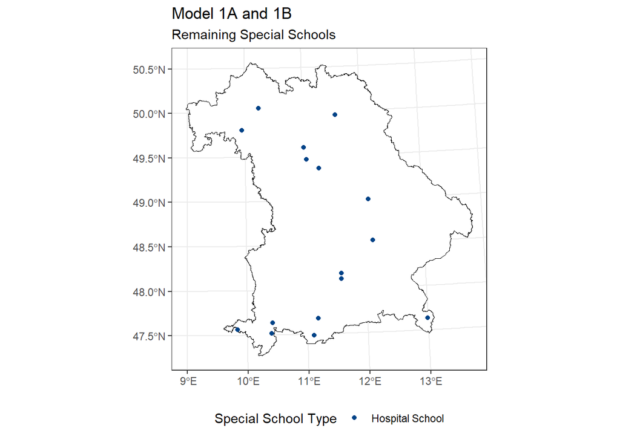

```r
plot <- model_1a %>%
  select(Type, Schultyp, SFZ, RS_Kreis, lat, lon) %>%
  mutate(Schule_Type = case_when(Schultyp == "Kranke" ~ "Hospital School",
                             SFZ == "1" ~ "Learning / Speech / Behavior",
                             SFZ == "0" ~ "Other",
                             TRUE ~ "Primary School")) %>%
  filter(!is.na(lat)) %>% st_as_sf(coords = c("lon", "lat"), crs=4326)

ggplot() +
  geom_sf(data=bavaria %>% filter(GEN=="Bayern") %>% select(GEN),
          aes(), color="black", fill="white") +
  geom_sf(data=plot %>% filter(Type == "SS"), aes(color=Schule_Type)) +
  scale_color_highcontrast() +
  theme_bw() +
  theme(legend.position = "bottom") +
  labs(color="Special School Type",
       title="Model 1A and 1B",
       subtitle="Remaining Special Schools")
```

## 6.3 Maps of Model 2A and 2B for all Bavaria

This map again follows the same cartographic workflow, but now the scenario reflects **partial closure**: only special schools for learning/behavior/speech (SFZ) are closed, while other special school types remain.

From a geodata perspective, this is a useful example of how maps can be used not only for communication but also for model validation: the remaining special schools should appear more numerous and geographically broader than in Model 1, because only one subgroup of special schools is removed.

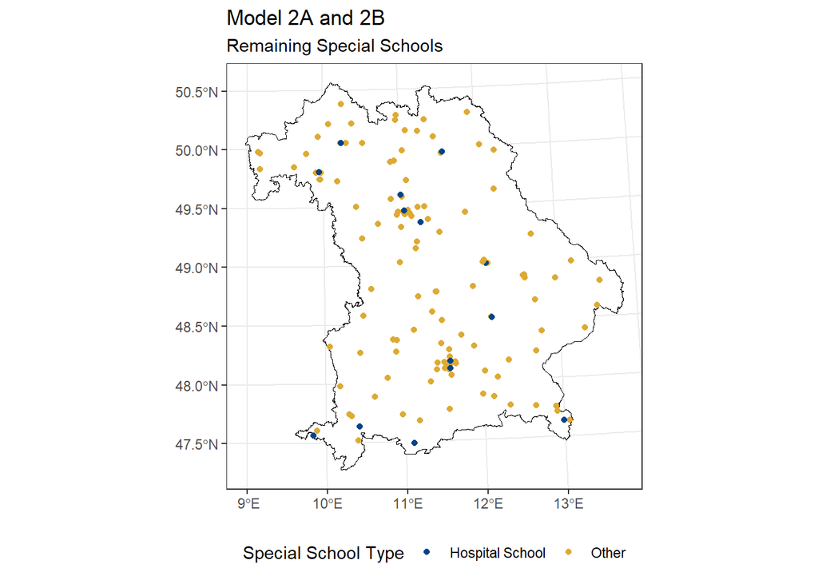

```r
plot <- model_2a %>%
  select(Type, Schultyp, SFZ, RS_Kreis, lat, lon) %>%
  mutate(Schule_Type = case_when(Schultyp == "Kranke" ~ "Hospital School",
                             SFZ == "1" ~ "Learning / Speech / Behavior",
                             SFZ == "0" ~ "Other",
                             TRUE ~ "Primary School")) %>%
  filter(!is.na(lat)) %>% st_as_sf(coords = c("lon", "lat"), crs=4326)

ggplot() +
  geom_sf(data=bavaria %>% filter(GEN=="Bayern") %>% select(GEN),
          aes(), color="black", fill="white") +
  geom_sf(data=plot %>% filter(Type == "SS"), aes(color=Schule_Type)) +
  scale_color_highcontrast() +
  theme_bw() +
  theme(legend.position = "bottom") +
  labs(color="Special School Type",
       title="Model 2A and 2B",
       subtitle="Remaining Special Schools")
```

## 6.4 Maps of Inclusive Primary Schools in Model 1B and 2B

The final cartographic subsection visualises the spatial distribution of **inclusive primary schools** in the selective inclusion scenarios (Models 1B and 2B). The core difference compared to the earlier maps is that the plotted points are no longer “special schools”, but primary schools classified as inclusive based on the simulation logic.

A new categorical variable (`Schule_Type`) is created to label schools as:

- Hospital School
- Learning/Speech/Behavior special school
- Inclusive Primary School
- Other special school
- Regular Primary School

In the plot, only schools labeled **“Inclusive Primary School”** are displayed as points. This produces a map of the *resulting institutional geography* of inclusion: where inclusive schools are located, and how concentrated or dispersed they are across Bavaria.

As before, the technical steps are:

- Create a point sf object with `st_as_sf()` using `(lon, lat)` and CRS 4326.
- Plot Bavaria as polygon background.
- Add inclusive primary schools as a point layer.
- Use a consistent theme and an accessible colour scale.

Interpreting these maps is straightforward even without geodata expertise: if inclusive schools cluster strongly in certain parts of Bavaria (e.g., around urban centres), this indicates that the size-based selection mechanism tends to concentrate inclusion geographically; if they are more evenly spread, the mechanism produces a more spatially balanced system.

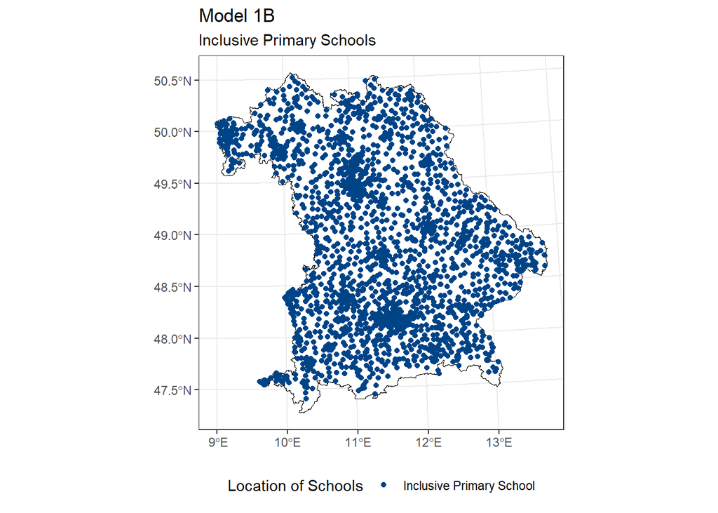

```r
plot <- model_1b %>%
  mutate(Schule_Type = case_when(Schultyp == "Kranke" ~ "Hospital School",
                             SFZ == "1" ~ "Learning / Speech / Behavior",
                             SFZ == "0" & !is.na(n_students_PS_new) ~ "Inclusive Primary School",
                             SFZ == "0" & Type=="SS"  ~ "Other",
                             TRUE ~ "Regular Primary School")) %>%
  select(Type, Schule_Type, Schultyp, SFZ, RS_Kreis, lat, lon) %>%
  filter(!is.na(lat)) %>% st_as_sf(coords = c("lon", "lat"), crs=4326)

ggplot() +
  geom_sf(data=bavaria %>% filter(GEN=="Bayern") %>% select(GEN),
          aes(), color="black", fill="white") +
  geom_sf(data=plot %>% filter(Schule_Type == "Inclusive Primary School"),
          aes(color=Schule_Type)) +
  scale_color_highcontrast() +
  theme_bw() +
  theme(legend.position = "bottom") +
  labs(color="Location of Schools",
       title="Model 1B",
       subtitle="Inclusive Primary Schools")
```

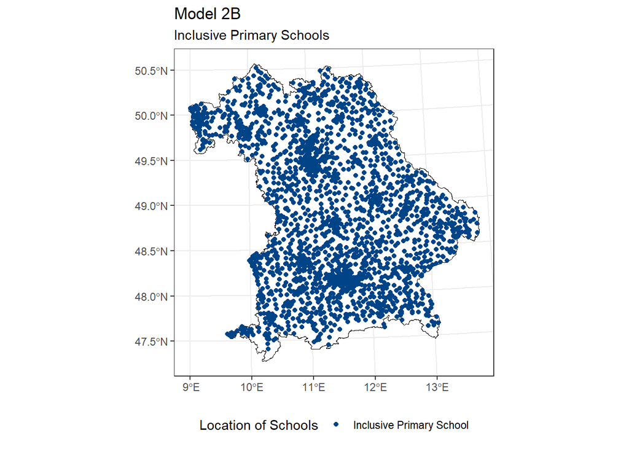

```r
plot <- model_2b %>%
  mutate(Schule_Type = case_when(Schultyp == "Kranke" ~ "Hospital School",
                             SFZ == "1" ~ "Learning / Speech / Behavior",
                             SFZ == "0" & !is.na(n_students_PS_new) ~ "Inclusive Primary School",
                             SFZ == "0" & Type=="SS"  ~ "Other",
                             TRUE ~ "Regular Primary School")) %>%
  select(Type, Schule_Type, Schultyp, SFZ, RS_Kreis, lat, lon) %>%
  filter(!is.na(lat)) %>% st_as_sf(coords = c("lon", "lat"), crs=4326)

ggplot() +
  geom_sf(data=bavaria %>% filter(GEN=="Bayern") %>% select(GEN),
          aes(), color="black", fill="white") +
  geom_sf(data=plot %>% filter(Schule_Type == "Inclusive Primary School"),
          aes(color=Schule_Type)) +
  scale_color_highcontrast() +
  theme_bw() +
  theme(legend.position = "bottom") +
  labs(color="Location of Schools",
       title="Model 2B",
       subtitle="Inclusive Primary Schools")
```

# 7. Analysis of Student Numbers

This section compares the simulation scenarios with respect to how student numbers and support rates would change at **primary schools**. The central idea is to bring all model outputs into a single harmonised dataset and then visualise key outcome indicators across scenarios. This approach makes it possible to compare distributions (not just averages) and to examine whether patterns differ between **urban and rural** contexts.

First, all five model datasets are stacked into one long data frame using `bind_rows()`. Each dataset receives a model label (`Modell`) so that results can later be grouped and plotted by scenario. In addition, settlement structure is simplified into a binary classification (`settlement`), where categories 1–2 are coded as **urban** and categories 3–4 as **rural**. This creates a clear grouping variable for stratified comparisons and reduces complexity for readers.

## 7.1 Primary school size after redistribution

```r
data_all <- bind_rows(
  model_0 %>% mutate(Modell = "0"),
  model_1a %>% mutate(Modell = "1a"),
  model_1b %>% mutate(Modell = "1b"),
  model_2a %>% mutate(Modell = "2a"),
  model_2b %>% mutate(Modell = "2b")) %>%
  mutate(settlement = case_when(SN_KTYP4 == 1 ~ "urban",
                                SN_KTYP4 == 2 ~ "urban",
                                SN_KTYP4 == 3 ~ "rural",
                                SN_KTYP4 == 4 ~ "rural"))
```

```r
pdlot <- data_all %>% filter(Type == "PS")

ggplot(plot, aes(x = Modell, y = n_students_PS_new, fill=settlement)) +
  geom_boxplot() +
  scale_fill_bright() +
  theme_bw() +
  theme(legend.position = "bottom") +
  labs(y = "N students per primary school",
       title = "How many students would be at one primary schools?",
       subtitle = "Model comparison", fill = "settlement structure")
```

[output not shown]

[output not shown]

## 7.2 Relative growth of primary schools

Absolute enrollment changes can be difficult to interpret across schools of different sizes. Therefore, the second plot focuses on **relative growth**, expressed as the percentage increase in enrollment attributed to newly redistributed students (`prop_students_PS_add`). This indicator captures how strongly each primary school would be affected relative to its starting size.

For the baseline scenario (Model 0), this variable is not defined, so the analysis restricts the data to the reform models (`Modell != "0"`). Missing values are recoded to zero to ensure that schools receiving no additional students are explicitly represented as “no change” rather than being dropped from the distribution.

Again, a boxplot is used to compare distributions across models and settlement structure. This representation is helpful for identifying whether particular models create more extreme “growth burdens” for a subset of schools.

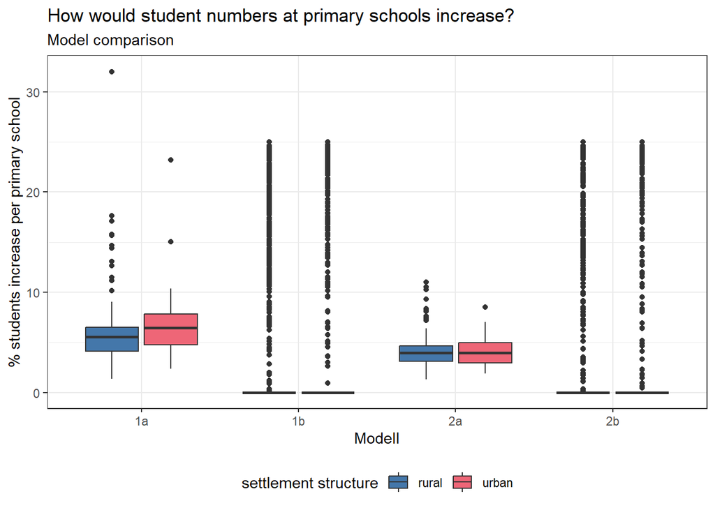

```r
plot <- data_all %>%
  filter(Type == "PS") %>% filter(Modell != "0") %>%
  mutate(prop_students_PS_add = case_when(is.na(prop_students_PS_add) ~ 0,
                                          TRUE ~ prop_students_PS_add))

ggplot(plot, aes(x = Modell, y = prop_students_PS_add, fill=settlement)) +
  geom_boxplot() +
  scale_fill_bright() +
  theme_bw() +
  theme(legend.position = "bottom") +
  labs(y = "% students increase per primary school",
       title = "How would student numbers at primary schools increase?",
       subtitle = "Model comparison", fill = "settlement structure")
```

## 7.3 Support rates after redistribution

Beyond student numbers, a central outcome for inclusive schooling is the **support rate**, defined as the percentage of students with SEN in a primary school. In the baseline model, this is stored in `prop_support_rate`, whereas the simulated models store the updated rate in `prop_support_rate_new`. To make all scenarios comparable in a single plot, the code constructs a harmonised variable: for Model 0 it uses the observed baseline rate, and for all other models it uses the simulated rate.

A **violin plot** is used in this step instead of a boxplot. Violin plots display the full distribution shape (density), which is useful here because policy changes may not only shift medians but also change the overall dispersion and the presence of multi-modal patterns (e.g., if some schools become highly concentrated SEN sites while others remain unchanged, like it is the case with inclusive primary schools with 20% support rate). As in the previous figures, results are stratified by urban versus rural settlement structure.

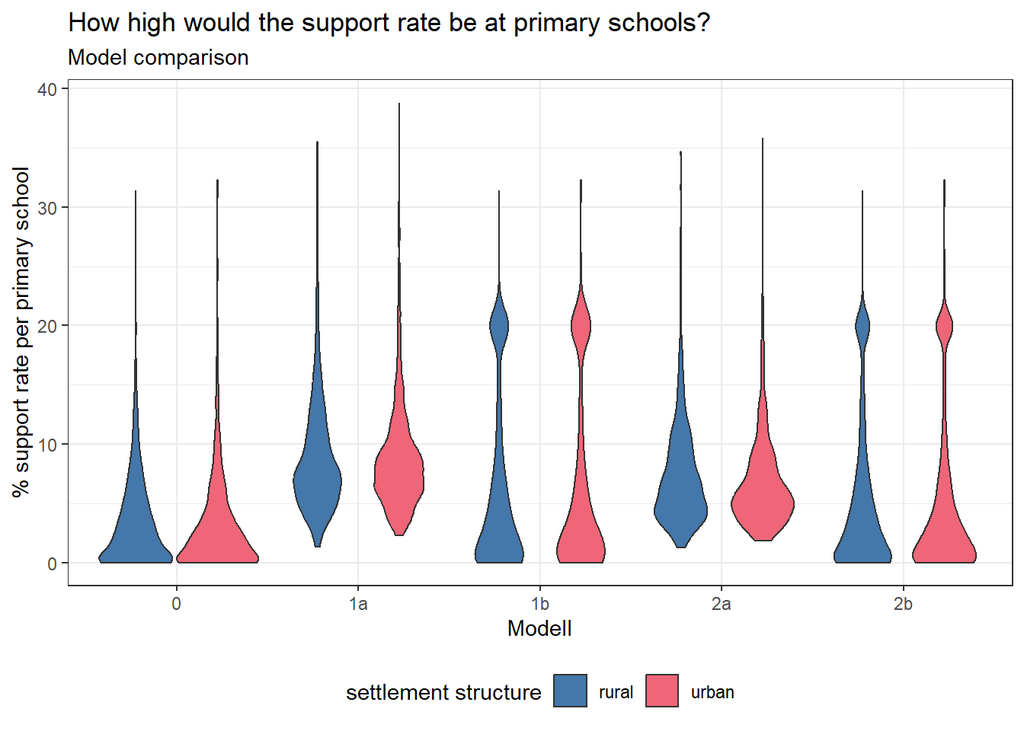

```r
plot <- data_all %>% filter(Type == "PS") %>%
  mutate(prop_support_rate_new = case_when(Modell == "0" ~ prop_support_rate,
                                           TRUE ~ prop_support_rate_new))

ggplot(plot, aes(x = Modell, y = prop_support_rate_new, fill=settlement)) +
  geom_violin() +
  scale_fill_bright() +
  theme_bw() +
  theme(legend.position = "bottom") +
  labs(y = "% support rate per primary school",
       title = "How high would the support rate be at primary schools?",
       subtitle = "Model comparison", fill = "settlement structure")
```

## 7.4 Increase in support rates relative to the baseline

Finally, the analysis focuses on the *change* in support rates relative to the current system. For each school, the baseline support rate is subtracted from the simulated support rate, producing `prop_support_rate_add`. This directly answers the question: **By how many percentage points would the SEN share increase at a primary school under each scenario?**

The baseline scenario is excluded because it would mechanically yield zero change. The resulting distribution of support-rate increases is visualised via boxplots across models and settlement structure. This view is particularly helpful for evaluating policy designs in terms of equity and feasibility: a model that produces modest and broadly shared increases may be operationally different from a model that produces large increases concentrated in a subset of schools.

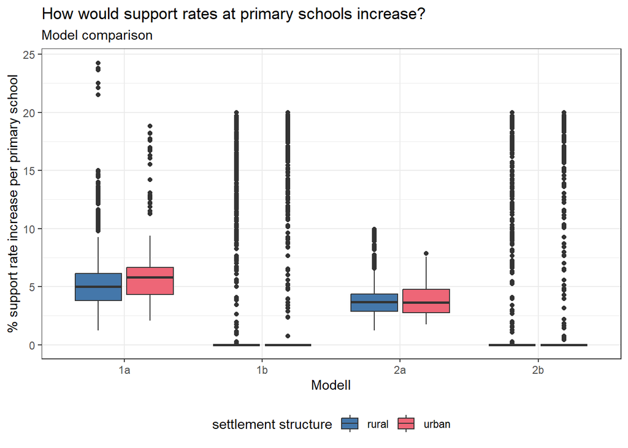

```r
plot <- data_all %>%
  filter(Type == "PS") %>% filter(Modell != "0") %>%
  mutate(prop_support_rate_add = prop_support_rate_new-prop_support_rate)

ggplot(plot, aes(x = Modell, y = prop_support_rate_add, fill=settlement)) +
  geom_boxplot() +
  scale_fill_bright() +
  theme_bw() +
  theme(legend.position = "bottom") +
  labs(y = "% support rate increase per primary school",
       title = "How would support rates at primary schools increase?",
       subtitle = "Model comparison", fill = "settlement structure")
```

# 8. Special educator distribution

The simulation models above describe how students with special educational needs (SEN) would be redistributed across primary schools after different closure policies. In practice, structural change also affects the allocation of **special education resources**. This section therefore translates the simulated number of students with SEN at each school into an estimate of **weekly special education teacher hours** and the corresponding demand for (full-time equivalent) special educators.

## 8.1 Deriving proportional allocation factors

The first step is to define a proportionality factor that converts “number of students with SEN” into “available special education teacher hours.” The analysis uses a fixed total amount of special education teacher hours as a resource envelope (here: 218,087.7 hours). For the scenarios in this report, only half of this total is used, reflecting the focus on the primary level.

For **Model 1**, the proportionality factor (`propfac_1`) is computed by dividing the available hours (50% of the total) by the total number of students with SEN in the simulated system (`sum(model_1a$n_students_SEN_new)`). Conceptually, this produces “hours per SEN student” under a proportional distribution rule.

For **Model 2**, fewer resources are assumed to be available. Specifically, the total hours are set to 60% of the Model 1 envelope (still restricted to 50% for primary level). The proportionality factor (`propfac_2`) is calculated analogously using the total number of students with SEN in Model 2A.

These factors allow the analysis to scale teacher resources consistently across models while keeping the overall resource assumptions transparent.

## 8.2 Allocating teacher hours to schools

A reusable function (`function2`) is defined to apply the proportional allocation rule to any simulated dataset. For each school, weekly special education hours are calculated as:

- `teacher_hours = n_students_SEN_new * propfac`

This means that schools with more students with SEN receive proportionally more weekly special education hours.

To improve interpretability, the analysis also converts hours into an estimate of full-time equivalents (FTE). Here, **26 hours per week** are treated as one full-time special educator position:

- `n_speced_teachers = teacher_hours / 26`

In addition to school-level resource estimates, district-level aggregates are calculated by grouping the data by district (`RS_Kreis`) and summing teacher hours across all schools in the district:

- `teacher_hours_Kreis`: total weekly special education hours per district
- `teachers_Kreis`: district-level FTE estimate (hours divided by 26)

Finally, settlement structure categories are prepared for later comparisons. The variable `SN_KTYP4` is converted into a factor and recoded into an English-labelled categorical variable (`SN_KTYP4_ENG`) distinguishing large cities, urban districts, rural districts, and sparsely populated districts. The factor levels are explicitly ordered to ensure consistent plotting and reporting. Each output dataset also receives a simulation identifier (`sim`) so that Model 1 and Model 2 outputs can be compared in a combined framework later.

## 8.3 Applying the allocation to the simulated systems

The function is then applied to:

- **Model 1A** (full closure of special schools with proportional redistribution to primary schools), producing `model1` using `propfac_1`.
- **Model 2A** (closure of SFZ schools only with proportional redistribution), producing `model2` using `propfac_2`.

The subsequent `head()` outputs are included to document the structure of the resulting datasets and to confirm that teacher-hour and FTE variables were generated as intended.

Overall, this section operationalises a simple but transparent resource model: special education capacity is treated as a limited budget of weekly hours, distributed proportionally to the simulated number of SEN students across schools and districts. This provides a resource-based perspective on the feasibility and implications of the simulated structural reforms.

```r
# Calculation of proportion factors
## Model 1 (50% teacher hours / all students with SEN)
propfac_1 <- (218087.7/2) / sum(model_1a$n_students_SEN_new, na.rm=T)
## Model 2 (60% of model 1 teacher hours / all students with SEN)
propfac_2 <- (218087.7/2)*0.6 / sum(model_2a$n_students_SEN_new, na.rm=T)

# Function for Distribution of special educator hours
function2 <- function(d, propfac, sim_number) {
  result <- d %>%
  mutate(teacher_hours = n_students_SEN_new*propfac) %>%
  mutate(n_speced_teachers = teacher_hours/26) %>%
  group_by(RS_Kreis) %>%
  mutate(teacher_hours_Kreis = sum(teacher_hours, na.rm=T)) %>%
  mutate(teachers_Kreis = teacher_hours_Kreis/26) %>%
  mutate(SN_KTYP4 = as.factor(SN_KTYP4)) %>%
  mutate(SN_KTYP4_ENG = case_when(
    SN_KTYP4==1 ~ "large cities", SN_KTYP4==2 ~ "urban districts",
    SN_KTYP4==3 ~ "rural districts", SN_KTYP4==4 ~ "sparsley\npopulated")) %>%
  mutate(SN_KTYP4_ENG = factor(SN_KTYP4_ENG,
    levels=c("large cities", "urban districts",
             "rural districts", "sparsley\npopulated"))) %>%
  mutate(sim = sim_number) %>% ungroup()
  return(result)}

# Distribution Model 1
model1 <- function2(model_1a, propfac_1, 1)

# Distribution Model 1
model2 <- function2(model_2a, propfac_2, 2)
```

```r
head(model1)
```

| Schulnummer | Type | Schultyp | SFZ | SN_KTYP4 | RS_Kreis | Kreis | Gemeindekennzahl | Strasse | PLZ | Ort | lat | lon | n_students_school | n_students_SEN_primary | n_students_district | n_students_SS_district | n_students_PS_district | n_students_SFZ_district | n_students_noSEN_district | prop_PS_size_district | prop_support_rate | n_students_PS_new | n_students_PS_add | prop_students_PS_add | prop_support_rate_new | n_students_SEN_new | teacher_hours | n_speced_teachers | teacher_hours_Kreis | … |
| --- | --- | --- | --- | --- | --- | --- | --- | --- | --- | --- | --- | --- | --- | --- | --- | --- | --- | --- | --- | --- | --- | --- | --- | --- | --- | --- | --- | --- | --- | --- |
| 1203 | PS | Grund- u. Mittelschule | 0 | 2 | 9171 | Altötting | 9171125 | Simbacher Str. 10/12 | 84524 | Neuötting | 48.24050 | 12.69665 | 299 | 14 | 4199 | 237 | 3962 | 186.5 | 3847 | 0.0754669 | 4.6822742 | 316.8857 | 17.885664 | 5.981827 | 10.062198 | 31.885664 | 82.31284 | 3.1658785 | 908.688 | … |
| 1204 | PS | Grund- u. Mittelschule | 0 | 2 | 9171 | Altötting | 9171133 | Burgkirchener Str. 5 | 84577 | Tüßling | 48.21160 | 12.60343 | 104 | 5 | 4199 | 237 | 3962 | 186.5 | 3847 | 0.0262494 | 4.8076923 | 110.2211 | 6.221101 | 5.981827 | 10.180537 | 11.221101 | 28.96727 | 1.1141258 | 908.688 | … |
| 1205 | PS | Grund- u. Mittelschule | 0 | 4 | 9173 | Bad Tölz-Wolfratshausen | 9173112 | Krankenhausstr. 45 | 83646 | Bad Tölz | 47.75604 | 11.56523 | 181 | 11 | 4717 | 252 | 4465 | 199.0 | 4305 | 0.0405375 | 6.0773481 | 191.2155 | 10.215454 | 5.643897 | 11.095052 | 21.215453 | 54.76769 | 2.1064497 | 1063.578 | … |
| populated | 1 |  |  |  |  |  |  |  |  |  |  |  |  |  |  |  |  |  |  |  |  |  |  |  |  |  |  |  |  | … |
| 1206 | PS | Grund- u. Mittelschule | 0 | 4 | 9173 | Lkr. Bad Tölz-Wolfratshausen | 173112 | Jahnstr. 9 | 83646 | Bad Tölz | 47.76591 | 11.56249 | 201 | 7 | 4717 | 252 | 4465 | 199.0 | 4305 | 0.0450168 | 3.4825871 | 212.3442 | 11.344233 | 5.643897 | 8.638913 | 18.344233 | 47.35564 | 1.8213707 | 1063.578 | … |
| populated | 1 |  |  |  |  |  |  |  |  |  |  |  |  |  |  |  |  |  |  |  |  |  |  |  |  |  |  |  |  | … |
| 1207 | PS | Grund- u. Mittelschule | 0 | 4 | 9173 | Lkr. Bad Tölz-Wolfratshausen | 173113 | Ludlmühlstr. 17 | 83671 | Benediktbeuern | 47.71205 | 11.42014 | 205 | 7 | 4717 | 252 | 4465 | 199.0 | 4305 | 0.0459127 | 3.4146341 | 216.5700 | 11.569989 | 5.643897 | 8.574590 | 18.569989 | 47.93843 | 1.8437856 | 1063.578 | … |
| populated | 1 |  |  |  |  |  |  |  |  |  |  |  |  |  |  |  |  |  |  |  |  |  |  |  |  |  |  |  |  | … |
| 1208 | PS | Grund- u. Mittelschule | 0 | 4 | 9173 | Lkr. Bad Tölz-Wolfratshausen | 173118 | Am Richteranger 12 - 18 | 83623 | Dietramszell | 47.84911 | 11.59473 | 159 | 1 | 4717 | 252 | 4465 | 199.0 | 4305 | 0.0356103 | 0.6289308 | 167.9738 | 8.973796 | 5.643897 | 5.937710 | 9.973796 | 25.74735 | 0.9902829 | 1063.578 | … |
| populated | 1 |  |  |  |  |  |  |  |  |  |  |  |  |  |  |  |  |  |  |  |  |  |  |  |  |  |  |  |  | … |

```r
head(model2)
```

| Schulnummer | Type | Schultyp | SFZ | SN_KTYP4 | RS_Kreis | Kreis | Gemeindekennzahl | Strasse | PLZ | Ort | lat | lon | n_students_school | n_students_SEN_primary | n_students_district | n_students_SS_district | n_students_PS_district | n_students_SFZ_district | n_students_noSEN_district | prop_PS_size_district | prop_support_rate | n_students_PS_new | n_students_PS_add | prop_students_PS_add | prop_support_rate_new | n_students_SEN_new | teacher_hours | n_speced_teachers | teacher_hours_Kreis | … |
| --- | --- | --- | --- | --- | --- | --- | --- | --- | --- | --- | --- | --- | --- | --- | --- | --- | --- | --- | --- | --- | --- | --- | --- | --- | --- | --- | --- | --- | --- | --- |
| 753 | SS | KME | 0 | 1 | 9162 | Krfr. St. München | 162000 | Kurzstr. 2 | 81547 | München | 48.10467 | 11.56889 | 112.5 | NA | 48699.5 | 3008.5 | 45691 | 1800.0 | 44533 | 0.0024622 | NA | 116.9319 | 4.431945 | 3.939507 | NA | NA | NA | NA | 5907.5404 | … |
| 1203 | PS | Grund- u. Mittelschule | 0 | 2 | 9171 | Altötting | 9171125 | Simbacher Str. 10/12 | 84524 | Neuötting | 48.24050 | 12.69665 | 299.0 | 14 | 4199.0 | 237.0 | 3962 | 186.5 | 3847 | 0.0754669 | 4.682274 | 313.0746 | 14.074583 | 4.707219 | 8.967379 | 28.074583 | 56.06888 | 2.1564953 | 602.1377 | … |
| 1204 | PS | Grund- u. Mittelschule | 0 | 2 | 9171 | Altötting | 9171133 | Burgkirchener Str. 5 | 84577 | Tüßling | 48.21160 | 12.60343 | 104.0 | 5 | 4199.0 | 237.0 | 3962 | 186.5 | 3847 | 0.0262494 | 4.807692 | 108.8955 | 4.895507 | 4.707219 | 9.087158 | 9.895507 | 19.76271 | 0.7601044 | 602.1377 | … |
| 1205 | PS | Grund- u. Mittelschule | 0 | 4 | 9173 | Bad Tölz-Wolfratshausen | 9173112 | Krankenhausstr. 45 | 83646 | Bad Tölz | 47.75604 | 11.56523 | 181.0 | 11 | 4717.0 | 252.0 | 4465 | 199.0 | 4305 | 0.0405375 | 6.077348 | 189.0670 | 8.066965 | 4.456887 | 10.084768 | 19.066965 | 38.07940 | 1.4645924 | 716.9733 | … |
| populated | 2 |  |  |  |  |  |  |  |  |  |  |  |  |  |  |  |  |  |  |  |  |  |  |  |  |  |  |  |  | … |
| 1206 | PS | Grund- u. Mittelschule | 0 | 4 | 9173 | Lkr. Bad Tölz-Wolfratshausen | 173112 | Jahnstr. 9 | 83646 | Bad Tölz | 47.76591 | 11.56249 | 201.0 | 7 | 4717.0 | 252.0 | 4465 | 199.0 | 4305 | 0.0450168 | 3.482587 | 209.9583 | 8.958343 | 4.456887 | 7.600719 | 15.958343 | 31.87105 | 1.2258095 | 716.9733 | … |
| populated | 2 |  |  |  |  |  |  |  |  |  |  |  |  |  |  |  |  |  |  |  |  |  |  |  |  |  |  |  |  | … |
| 1207 | PS | Grund- u. Mittelschule | 0 | 4 | 9173 | Lkr. Bad Tölz-Wolfratshausen | 173113 | Ludlmühlstr. 17 | 83671 | Benediktbeuern | 47.71205 | 11.42014 | 205.0 | 7 | 4717.0 | 252.0 | 4465 | 199.0 | 4305 | 0.0459127 | 3.414634 | 214.1366 | 9.136618 | 4.456887 | 7.535665 | 16.136618 | 32.22709 | 1.2395034 | 716.9733 | … |
| populated | 2 |  |  |  |  |  |  |  |  |  |  |  |  |  |  |  |  |  |  |  |  |  |  |  |  |  |  |  |  | … |

# 9. Matching Schools

The redistribution models in this report assume that students with special educational needs (SEN) move into primary schools. In many schools — especially smaller ones — this implies only a limited demand for special education capacity. In practice, special educators are therefore often not assigned as a full-time position to every single school. Instead, they may work **across multiple schools**, for example as mobile staff serving a cluster of nearby schools.

This section operationalises that idea by identifying primary schools whose estimated weekly special education demand is **below one full-time position** (defined here as 26 hours per week) and pairing them into geographically plausible “mobile service groups.” The goal is to form pairs of schools that are **close to each other**, while also aiming for a meaningful combination of workload.

The matching procedure is applied separately within each district. This reflects an administrative assumption: mobile support is most realistically organised **within district boundaries**, because staff deployment, budgeting, and coordination typically follow district jurisdictions.

Within each district, the algorithm focuses on the subset of primary schools that have **teacher_hours < 26**. These are schools where the estimated demand does not justify a full-time special educator position. The algorithm then forms pairs of schools so that the combined demand can be treated as a practical service unit (e.g., one teacher covering two sites).

Two criteria guide the pairing:

1. **Minimise geographic distance** between schools (to reduce travel time and organisational friction).
2. **Prefer larger differences in teacher-hour demand when distance is equal**, so that pairs can combine a “higher-need” school with a “lower-need” school rather than clustering only very small demands together.

## 9.1 Greedy Algorithm

The function `function3()` implements a **greedy matching algorithm**, applied district by district. “Greedy” means that the algorithm selects the best available pair at each step, removes those schools from consideration, and repeats until no further pairs can be formed.

For each district, the procedure works as follows:

1. **Subset to one district:**  
   The data are filtered to the current district (`d_kreis`).
2. **Compute all pairwise geographic distances:**  
   A coordinate matrix is created from longitude and latitude (`coords`), and a distance matrix (`dist_matrix`) is calculated using `distm()` from the geosphere package. This produces the distance (in meters) between every pair of schools in the district.
3. **Define a workload difference function:**  
   A helper function computes the absolute difference in estimated teacher hours between two schools. This is later used as a tie-breaker.
4. **Iteratively select the “best” pair:**  
   While at least two unmatched schools remain, the algorithm tests all possible school pairs among the remaining schools and selects the pair that has the smallest distance, or in case of equal distance, has the largest difference in teacher-hour demand.
5. **Store pairs and remove matched schools:**  
   Once the best pair is found, the corresponding school IDs are saved, and both schools are removed from the list of remaining schools. The loop then continues with the remaining schools.

After all districts are processed, the list of pairs is converted into a tidy long-format dataset. Each pair receives a unique group identifier (`Group`), and the data are reshaped so that each school belongs to a group, which later allows the aggregation of information across paired schools.

The function `function3()` is designed to optionally join the generated pairs back to a full model dataset. When the argument `model` is provided, the function returns a school-level dataset with group membership included and adds group-level indicators:

- **`dist_km`**: the average within-group distance (converted to kilometres). This provides a measure of how far mobile staff would need to travel between paired schools.
- **`sum_hours`**: the combined weekly special education hours across the paired schools.
- **`sum_teachers`**: the combined demand expressed in full-time equivalents (sum_hours / 26).

The additional step using `fill(Group, .direction = "up")` and `fill(..., "down")` serves as a pragmatic way to assign a group label to schools when joining and ordering may leave temporary gaps. Conceptually, this ensures that the group identifier is consistently available for aggregation.

```r
# Greedy Algorithm per District
function3 <- function(df, model = NULL) {
  # New empty list to save school pairs
  pairs <- list()
  # Loop: Do it for every district!
  for (kreis in unique(df$RS_Kreis)) {
    # Filter the data
    d_kreis <- df %>% filter(RS_Kreis == kreis)
    # Create the coordinates matrix for distance calculation
    coords <- cbind(d_kreis$lon, d_kreis$lat)
    # Compute the distance matrix
    dist_matrix <- distm(coords)
    # Function to calculate the teacher hours difference
    teacher_diff <- function(i, j) {
      abs(d_kreis$teacher_hours[i] - d_kreis$teacher_hours[j])
    }
    # Number of schools, which need matching
    remaining_schools <- 1:nrow(d_kreis)
    # Do this, as long as more than 1 unmatched school remains
    while (length(remaining_schools) > 1) {
      # Create empty variables to save information
      best_pair <- NULL # Pair of school numbers
      best_distance <- Inf # Minimal distance
      best_teacher_diff <- -Inf # Largest teacher hour diff
      best_pair_index <- c() # Indices of best school pair
      # Select the first school to match
      for (i in 1:(length(remaining_schools) - 1)) {
        # Select second school, which matches the first school
        for (j in (i + 1):length(remaining_schools)) {
          # List the two schools to compare
          school_i <- remaining_schools[i]
          school_j <- remaining_schools[j]
          # Calculate the distance between the schools
          distance <- dist_matrix[school_i, school_j]
          # Calculate the teacher hour diff between the schools
          teacher_diff_value <- teacher_diff(school_i, school_j)
          if (is.na(distance) || is.na(teacher_diff_value)) next
          # If distance and teacher diff are better then other options,
          # choose this pair as matching pair
          if (distance < best_distance || (
            distance==best_distance&&teacher_diff_value>best_teacher_diff)) {
            # Save variables of matching pair
            best_pair <- c(school_i, school_j)
            best_distance <- distance
            best_teacher_diff <- teacher_diff_value
            best_pair_index <- c(i, j)
          }
        }
      }
      # Add the best pair to the list
      pairs <- c(pairs, list(c(d_kreis$Schulnummer[best_pair[1]],
                               d_kreis$Schulnummer[best_pair[2]])))
      # Remove the selected pair from the remaining schools
      remaining_schools <- remaining_schools[-c(best_pair_index)]
    }
  }
  # Create a DataFrame from the list of pairs for a better overview
  paired_schools <- do.call(rbind, pairs) %>%
    # List to dataframe
    as.data.frame() %>%
    # Rename columns
    rename(Schule_A = V1, Schule_B = V2) %>%
    # New column with pair-ID
    mutate(Group = paste0(pmin(Schule_A, Schule_B), "_",
                          pmax(Schule_A, Schule_B))) %>%
    # Restructure df: Every row is a school
    pivot_longer(c(Schule_A, Schule_B), values_to = "Schulnummer") %>%
    # Remove old variable
    select(-name)

  # Join the pairs and match left schools to nearest pair
  if (!is.null(model)) {
    model_matched <- model %>%
      # Join pairs and remove duplicates
      right_join(paired_schools) %>% unique() %>%
      # Sort distance between schools in a district
      arrange(RS_Kreis, lon, lat) %>% group_by(RS_Kreis) %>%
      # Manually match left schools to nearest district
      fill(Group, .direction = "up") %>% fill(Group, .direction = "down") %>%
      ungroup() %>% group_by(Group) %>%
      # Create new columns
      mutate(dist_km = mean(
        distm(matrix(c(lon, lat), ncol = 2)) / 1000, na.rm = T)) %>%
      mutate(dist_km = na_if(dist_km, 0)) %>%
      mutate(sum_hours = sum(teacher_hours)) %>%
      mutate(sum_teachers = sum_hours / 26)
    return(model_matched)
  }
  return(paired_schools)
}
```

## 9.2 Applying the algorithm

The pairing algorithm is applied separately to the two resource-allocation scenarios created in the previous section:

- `x1` uses the output dataset for Model 1 (based on Model 1A redistribution and the corresponding resource envelope).
- `x2` uses the output dataset for Model 2 (based on Model 2A redistribution and a reduced resource envelope).

In both cases, the matching is restricted to primary schools (`Type == "PS"`), schools with available coordinates (`!is.na(lat)`), and schools below the full-time threshold (`teacher_hours < 26`). This yields a paired structure for low-demand schools in each scenario.

```r
# Match schools without full-time special educators per district
x1 <- model1 %>%
  filter(teacher_hours < 26) %>%
  filter(!is.na(lat)) %>%
  filter(Type == "PS") %>%
  function3(model=model1)

x2 <- model2 %>%
  filter(teacher_hours < 26) %>%
  filter(!is.na(lat)) %>%
  filter(Type == "PS") %>%
  function3(model=model2)
```

Finally, the matched results are combined into a single dataset (`models`) to support later visualisations and descriptive statistics. Both matched datasets are appended and then joined back to the full model data so that matched and unmatched schools can be analyzed together.

Additional variables are computed:

- **`prop_matched`**: the proportion of schools in a district that do *not* have a matching group label (stored here as the share of missing group assignments). This provides a district-level indicator of how many schools remain “unpaired,” which may occur if a district has an odd number of low-demand schools or missing coordinate data.
- **`system`**: a readable label distinguishing Model 1 and Model 2.
- **`sum_hours`** is capped at 5,000 for plotting purposes to prevent extreme values from dominating the scale.

Overall, this section translates the simulated school-level demand for special education resources into a plausible organisational structure for mobile support provision. By combining geographic proximity with workload information, the matching procedure provides an interpretable approximation of how schools could be clustered to share special educators under different closure and redistribution scenarios.

```r
# Combine all information into one df and calculate new variables
models <- rbind(x1, x2) %>% ungroup() %>%
  full_join(model1) %>% full_join(model2) %>%
  group_by(RS_Kreis, sim) %>%
  # Proportion of matched schools / all schools in district
  mutate(prop_matched = (sum(is.na(Group)))/n()*100) %>%
  # Fot plots
  mutate(system = case_when(sim==1 ~ "Model 1", sim==2 ~ "Model 2")) %>%
  mutate(sum_hours = case_when(sum_hours > 5000 ~ 5000, TRUE ~ sum_hours)) %>%
  ungroup()

head(models)
```

| Schulnummer | Type | Schultyp | SFZ | SN_KTYP4 | RS_Kreis | Kreis | Gemeindekennzahl | Strasse | PLZ | Ort | lat | lon | n_students_school | n_students_SEN_primary | n_students_district | n_students_SS_district | n_students_PS_district | n_students_SFZ_district | n_students_noSEN_district | prop_PS_size_district | prop_support_rate | n_students_PS_new | n_students_PS_add | prop_students_PS_add | prop_support_rate_new | n_students_SEN_new | teacher_hours | n_speced_teachers | teacher_hours_Kreis | … |
| --- | --- | --- | --- | --- | --- | --- | --- | --- | --- | --- | --- | --- | --- | --- | --- | --- | --- | --- | --- | --- | --- | --- | --- | --- | --- | --- | --- | --- | --- | --- |
| 2316 | PS | Grund- u. Mittelschule | 0 | 1 | 9162 | München, Kfr. St. | 9162000 | Kaflerstr. 14 | 81241 | München | 48.14964 | 11.45847 | 96 | 0 | 48699.5 | 3008.5 | 45691 | 1800 | 44533 | 0.0021011 | 0.00000 | 102.32107 | 6.321070 | 6.584448 | 6.177682 | 6.321070 | 16.31784 | 0.6276093 | 10755.82 | … |
| 2310 | PS | Grund- u. Mittelschule | 0 | 1 | 9162 | München, Kfr. St. | 9162000 | Hinterbärenbadstr. 71 - 73 | 81373 | München | 48.12038 | 11.52062 | 64 | 0 | 48699.5 | 3008.5 | 45691 | 1800 | 44533 | 0.0014007 | 0.00000 | 68.21405 | 4.214047 | 6.584448 | 6.177682 | 4.214047 | 10.87856 | 0.4184062 | 10755.82 | … |
| 2077 | PS | Grund- u. Mittelschule | 0 | 1 | 9162 | München, Kfr. St. | 9162000 | Wolfratshauser Str. 84 | 81379 | München | 48.09337 | 11.53973 | 121 | 0 | 48699.5 | 3008.5 | 45691 | 1800 | 44533 | 0.0026482 | 0.00000 | 128.96718 | 7.967182 | 6.584448 | 6.177682 | 7.967182 | 20.56728 | 0.7910492 | 10755.82 | … |
| 2192 | PS | Grund- u. Mittelschule | 0 | 1 | 9162 | Krfr. St. München | 162000 | Herrnstr. 21 | 80539 | München | 48.13655 | 11.58128 | 92 | 3 | 48699.5 | 3008.5 | 45691 | 1800 | 44533 | 0.0020135 | 3.26087 | 98.05769 | 6.057692 | 6.584448 | 9.237105 | 9.057692 | 23.38243 | 0.8993243 | 10755.82 | … |
| 2197 | PS | Grund- u. Mittelschule | 0 | 1 | 9162 | Krfr. St. München | 162000 | Hochstr. 31 | 81669 | München | 48.12609 | 11.58688 | 93 | 0 | 48699.5 | 3008.5 | 45691 | 1800 | 44533 | 0.0020354 | 0.00000 | 99.12354 | 6.123536 | 6.584448 | 6.177682 | 6.123536 | 15.80791 | 0.6079965 | 10755.82 | … |
| 3070 | PS | Grund- u. Mittelschule | 0 | 1 | 9162 | München, Kfr. St. | 9162000 | Preysingstr. 83-105 | 81667 | München | 48.13232 | 11.59809 | 70 | 0 | 48699.5 | 3008.5 | 45691 | 1800 | 44533 | 0.0015320 | 0.00000 | 74.60911 | 4.609113 | 6.584448 | 6.177682 | 4.609113 | 11.89843 | 0.4576318 | 10755.82 | … |

# 10. Visualisation of teacher hours

This section visualises how special education resources would be distributed across Bavaria under the simulated scenarios. The aim is twofold: first, to describe **regional differences** in the availability of special education hours; second, to illustrate what a system of **mobile special educators** could look like when many schools have demand below one full-time position. The figures combine classic statistical summaries (boxplots and bar charts) with cartographic visualisations based on district polygons and school coordinates.

## 10.1 Teacher hours in all Bavaria

The first figure combines two spatial layers: district boundaries and point locations of special schools. To enable district-level mapping, the district shapefile is prepared by creating a numeric district identifier (`RS_Kreis`) from the official administrative code (`ARS`) and retaining only the variables needed for plotting (district name and geometry). The simulated model dataset is then joined to the district polygons so that each district polygon can be filled with the district-level indicator `teacher_hours_Kreis` (total weekly special education hours in that district).

Because the model data are primarily school-level tables, the join with `district_new` and the subsequent call to `st_as_sf()` ensure that the object used for mapping contains a valid **geometry column**. In other words, a normal data frame is turned into a spatial feature object by attaching district polygons. This enables the use of `geom_sf()` for a choropleth map.

In addition to the choropleth layer, special school locations are plotted as points. These are created by filtering for special schools (excluding hospital schools), selecting coordinates, and converting them to spatial points using `st_as_sf(coords = c("lon", "lat"), crs = 4326)`. This overlay serves as contextual information: it shows where special schools were located relative to the spatial distribution of teacher hours after redistribution.

The map is faceted by `system`, so Model 1 and Model 2 can be compared side-by-side. This is a practical way to communicate differences between scenarios while keeping the geographic reference constant. A sequential grey color scale is used for `teacher_hours_Kreis`, and extreme district values are capped for readability through defined limits and labelled breaks.

Overall, this figure provides a state-wide overview of how resources concentrate or disperse across districts under each scenario, and how this relates to the historical geography of special schools.

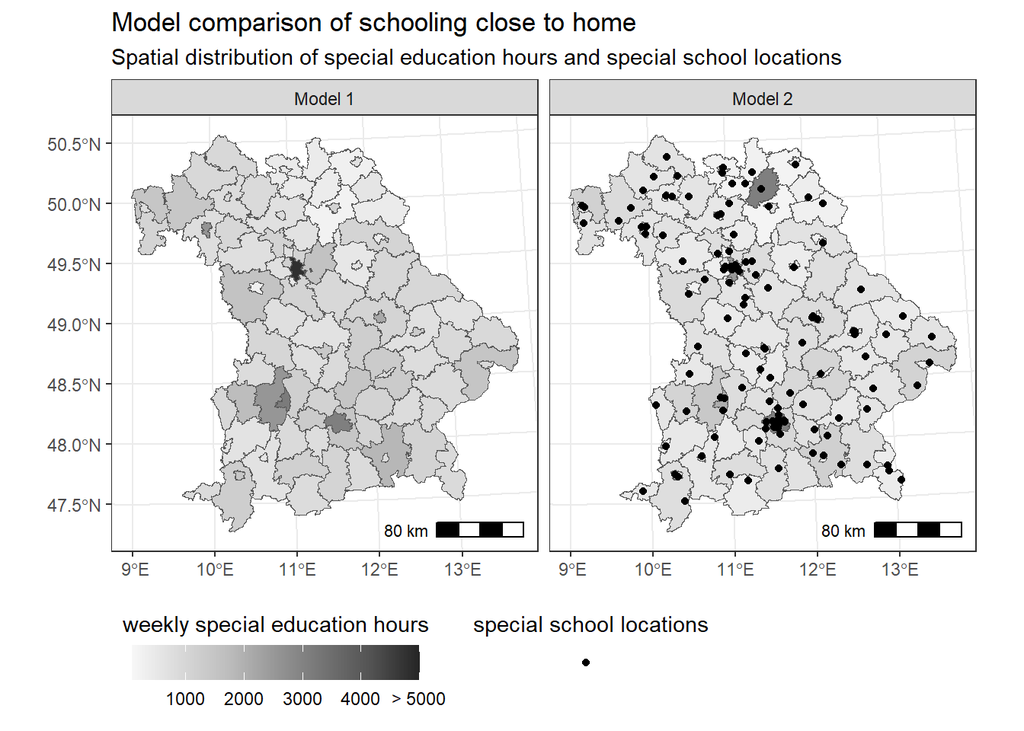

```r
district_new <- district %>%
  mutate(RS_Kreis = as.numeric(ARS)) %>% select(RS_Kreis, GEN, geometry)
x <- models %>% left_join(district_new) %>% st_as_sf()
y <- models %>% filter(Type == "SS" & Schultyp != "Kranke") %>%
  select(system, lat, lon) %>% st_as_sf(coords = c("lon", "lat"), crs=4326)

ggplot() +
  # Districts filled with teacher hours
  geom_sf(data=x, aes(geometry=geometry, fill=teacher_hours_Kreis)) +
  # Points of Schools
  geom_sf(data=y, aes(geometry=geometry, color="")) +
  # legend, margins and style
  labs(fill = "weekly special education hours", color="special school locations",
       title="Model comparison of schooling close to home",
       subtitle="Spatial distribution of special education hours and special school locations") +
  annotation_scale(location="br") +
  theme_bw() +
  theme(legend.position = "bottom", legend.justification = "left",
        legend.key.width=unit(1, "cm")) +
  facet_grid(cols = vars(system)) +
  # labels and text
  guides(
    fill = guide_colorbar(title.position = "top", order=1, title.hjust = 0.5),
    color = guide_legend(title.position = "top", order=2, title.hjust = 0.5)) +
  # colors
  scale_color_manual(values="black") +
  scale_fill_distiller(
    type="seq",direction=1,palette="Greys",limits=c(100,5000),
    breaks=c(1000, 2000, 3000, 4000, 5000),
    labels=c("1000", "2000", "3000", "4000", "> 5000"))
```

The second plot shifts from district polygons to a school-level distributional perspective. Weekly teacher hours at each school (`teacher_hours`) are compared across district settlement categories (`SN_KTYP4_ENG`) and across systems (Model 1 vs. Model 2). A boxplot is used to show whether certain settlement types systematically receive fewer or more hours per school, and whether the reduced resource envelope in Model 2 shifts the entire distribution downward.

A dashed horizontal line at 26 hours marks the operational threshold for a full-time position. This visual reference is important because it links the simulation output to an interpretable staffing benchmark: schools below this line are those that would typically require shared or mobile staffing solutions.

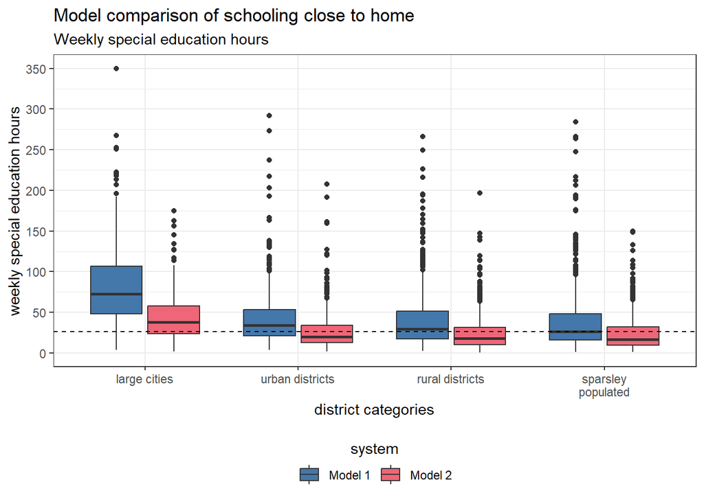

```r
models %>%
  ggplot(aes(y=teacher_hours, x=SN_KTYP4_ENG, fill=system)) +
  geom_boxplot()+ theme_bw() +
  # legend, margins and style
  theme(legend.position = "bottom") +
  # labels and text
  ylab("weekly special education hours") + xlab("district categories") +
  labs(subtitle="Weekly special education hours",
       title="Model comparison of schooling close to home") +
  guides(fill = guide_legend(title.position = "top", title.hjust = 0.5)) +
  # second y-axis
  scale_y_continuous("weekly special education hours", breaks = seq(0, 350, 50)) +
  # colors & lines
  scale_fill_bright() +
  geom_hline(yintercept = 26, linetype = "dashed", color = "black")
```

The third plot translates the continuous teacher-hour variable into a categorical indicator of staffing feasibility. Schools are classified as either having demand for “full position(s)” (≥ 26 hours) or “no full position” (< 26 hours). The figure then shows the proportion of schools in each category by model and settlement type using a stacked bar chart with `position = "fill"`, which normalises each bar to 100%.

This representation answers a practical implementation question: in which contexts (large cities vs. rural areas) and under which system (Model 1 vs. Model 2) would most schools require mobile staffing rather than a dedicated full-time special educator?

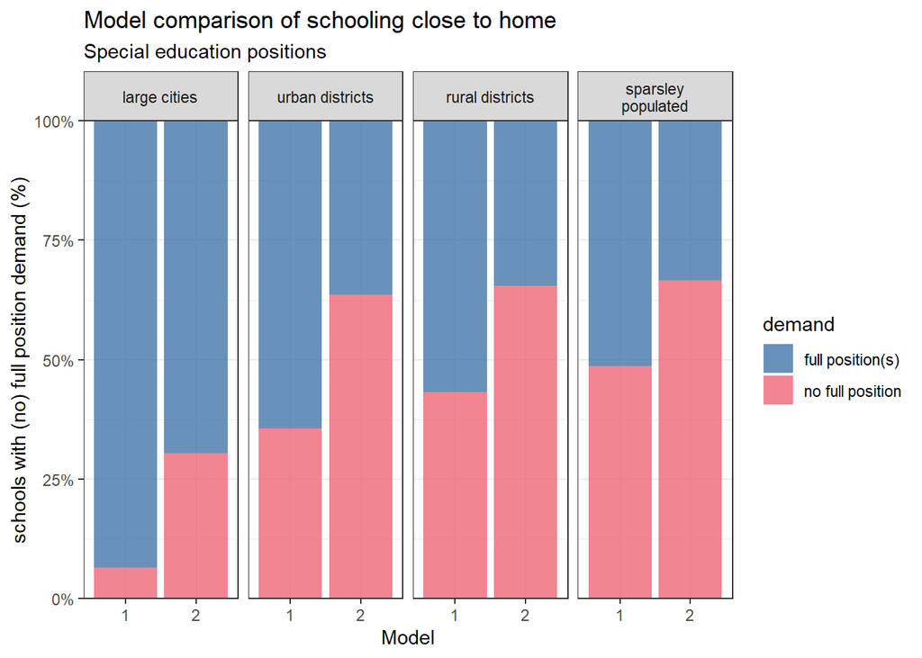

```r
models %>%
  mutate(demand = case_when(teacher_hours >=26 ~ "full position(s)",
                            teacher_hours < 26 ~ "no full position")) %>%
  mutate(system = case_when(system == "Model 1" ~ "1",
                            system == "Model 2" ~ "2")) %>%
  filter(!is.na(demand)) %>%
  ggplot(aes(x = system, fill = demand)) +
  facet_grid(cols = vars(SN_KTYP4_ENG)) +
  geom_bar(position = "fill", alpha=0.8) +
  scale_y_continuous(labels = scales::percent_format(),
                     expand = c(0, 0))  +
  labs(subtitle= "Special education positions",
       title="Model comparison of schooling close to home") +
  labs(y = "schools with (no) full position demand (%)", x = "Model") +
  theme(legend.position = "bottom",
        axis.title.x = element_text(margin=margin(t=-5))) +
  scale_fill_bright() +
  theme_bw()
```

## 10.2 Mobile special educators in specific regions

The next set of figures visualises the mobile staffing idea geographically using one example district (Tirschenreuth, RS_Kreis 9377). The underlying dataset contains both school coordinates and the group assignments generated by the matching procedure.

First, all schools with valid coordinates are converted into an sf point object (`models_sf`). Then, to represent “mobile service links” between paired schools, a line layer is generated (`models_lines`). This works by grouping schools by their matching group (`Group`) and merging their point geometries using `st_union()`, then casting the result to a `LINESTRING`. Conceptually, each line indicates a pair of schools that could plausibly share mobile special education staffing.

The maps for Model 1 and Model 2 follow the same structure:

- The district polygon is plotted as a grey background to provide geographic context.
- Schools are plotted as points, with point size proportional to `teacher_hours` to indicate the magnitude of demand at each school.
- Matching groups are displayed as lines connecting paired schools, illustrating the travel path implied by the pairing.

These maps are particularly useful for readers unfamiliar with geospatial analysis because they show, in a concrete way, how the abstract matching algorithm translates into a spatial service structure. Differences between Model 1 and Model 2 become visible not only in the size of points (less demand under Model 2), but potentially also in which schools are paired and how far mobile staff would need to travel.

```r
models_sf <- models %>% # Spatial Points
  filter(!is.na(lat)) %>%
  st_as_sf(coords = c("lon", "lat"), crs=4326)
models_lines <- models_sf %>% group_by(Group) %>% # Spatial Lines
  mutate(geometry = st_union(geometry) %>% st_cast("LINESTRING"))
```

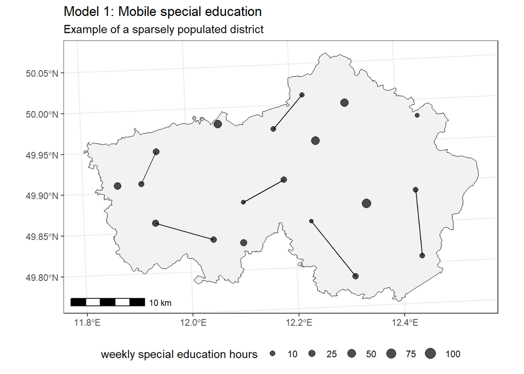

```r
ggplot() +
  # Map of Tirschenreuth
  geom_sf(data = district_new %>% filter(RS_Kreis=="9377") %>% select(geometry),
          fill = "grey95", color = "black") +
  # Points of Schools
  geom_sf(data=models_sf %>% filter(RS_Kreis == "9377") %>% filter(sim==1) %>%
            select(teacher_hours, geometry), aes(size=teacher_hours), alpha=0.7) +
  # Lines between Partner Schools
  geom_sf(data = models_lines %>% filter(RS_Kreis == "9377") %>% filter(sim==1) %>%
            filter(!is.na(Group)), aes(fill=Group)) +
  # Labs
  labs(subtitle="Example of a sparsely populated district",
       title="Model 1: Mobile special education") +
  # Customized Theme
  guides(fill = "none") + theme_bw() + annotation_scale() +
  theme(legend.position = "bottom") +
  scale_size_continuous(name = "weekly special education hours", guide = "legend",
                        breaks = c(10, 25, 50, 75, 100), limits=c(0, 200))
```

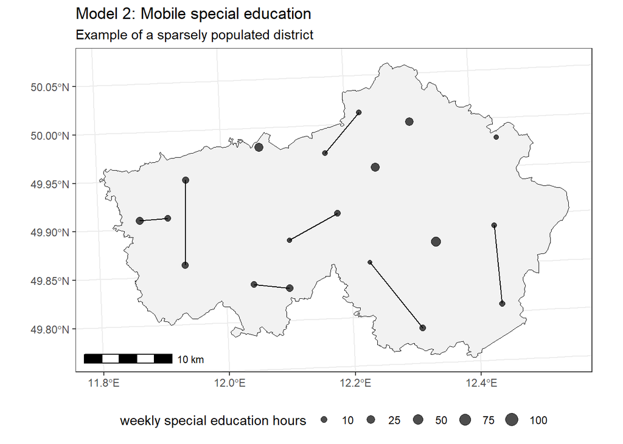

```r
ggplot() +
  # Map of Tirschenreuth
  geom_sf(data = district_new %>% filter(RS_Kreis=="9377") %>% select(geometry),
          fill = "grey95", color = "black") +
  # Points of Schools
  geom_sf(data=models_sf %>% filter(RS_Kreis == "9377") %>% filter(sim==2) %>%
            select(teacher_hours, geometry), aes(size=teacher_hours), alpha=0.7) +
  # Lines between Partner Schools
  geom_sf(data = models_lines %>% filter(RS_Kreis == "9377") %>% filter(sim==2) %>%
            filter(!is.na(Group)), aes(fill=Group)) +
  # Labs
  labs(subtitle="Example of a sparsely populated district",
       title="Model 2: Mobile special education") +
  # Customized Theme
  guides(fill = "none") + theme_bw() + annotation_scale() +
  theme(legend.position = "bottom") +
  scale_size_continuous(name = "weekly special education hours", guide = "legend",
                        breaks = c(10, 25, 50, 75, 100), limits=c(0, 200))
```

## 10.3 Mobile special education in all Bavaria

This subsection summarises the mobile staffing structure across Bavaria, using the group-level indicators created during the matching procedure.

The first boxplot compares the distribution of **combined special education hours per school pair** (`sum_hours`) across the two simulations (`sim`), stratified by settlement structure. This shows whether paired units in rural contexts tend to accumulate fewer or more hours than those in urban contexts and how sensitive this is to resource assumptions.

The second boxplot focuses on **distance between paired schools** (`dist_km`). This is a key operational metric: even if pairing is feasible in terms of combined workload, long travel distances may reduce effectiveness or increase organisational cost. Plotting distance by model and settlement type highlights whether mobile staffing is primarily an “urban convenience” or a “rural necessity,” and whether the simulated reform designs intensify travel burdens.

Together, these visualisations link the simulation results to implementation-relevant questions: where resources would be concentrated, how often schools would fall below a full-time threshold, and what a plausible spatial organisation of mobile support could look like under different structural reform scenarios.

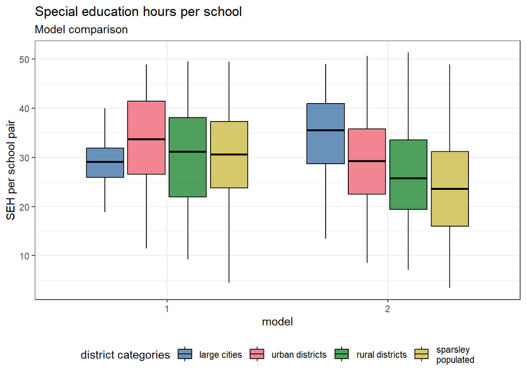

```r
models %>%
  ggplot(aes(fill=SN_KTYP4_ENG, y = sum_hours, x=as.factor(sim))) +
  geom_boxplot(color="black", alpha=0.8) +
  theme_bw() + theme(legend.position = "bottom") +
  scale_fill_bright() +
  labs(x="model", y="SEH per school pair", fill="district categories",
       title = "Special education hours per school",
       subtitle = "Model comparison")
```

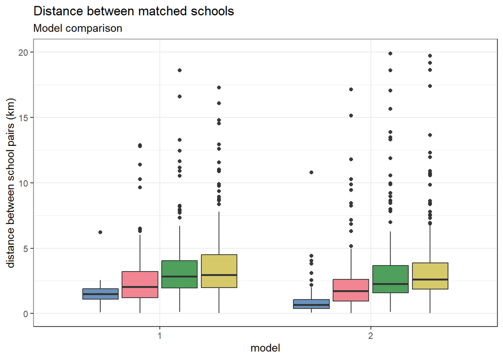

```r
models %>%
  ggplot(aes(fill=SN_KTYP4_ENG, y = dist_km, x=as.factor(sim))) +
  geom_boxplot(alpha=0.8) +
  theme_bw() + theme(legend.position = "none") +
  scale_fill_bright() +
  labs(x="model", y="distance between school pairs (km)",
       fill="district categories",
       title = "Distance between matched schools",
       subtitle = "Model comparison") +
  scale_y_continuous(breaks=seq(0, 30, 5), limits = c(0, 20))
```